# Projekt: Analiza ličnosti i njenih mračnih crta

Lana Barišić

Marta Leš

Lucija Lovrić

Karla Šoštar

2026-01-21

# Motivacija i opis problema

Ličnost je jedno od temeljnih područja psihologije i najčešće se opisuje petofaktorskim Big Five modelom koji uključuje ekstraverziju, ugodnost, savjesnost, neuroticizam i otvorenost. Uz osnovne crte ličnosti, često se ispituju i mračne crte, odnosno mračna trijada koju čine narcizam, psihopatija i makijavelizam. Cilj ovog projekta je ispitati povezanost osnovnih i mračnih crta ličnosti, te ostalih obilježja poput spola i dobi, sa sklonošću stresu, depresiji i anksioznosti.

# Učitavanje i pregled podataka

Podatke iz CSV datoteke učitavamo u varijablu *dataset* kako bismo ih mogle bolje analizirati.

```r
dataset <- read_csv('Personality_data.csv')
```

```
## ──────────────────────────────────────────────────────── Delimiter: "," chr
## (5): age, sex, ethnicity simplified, student status, employment status dbl
## (13): ...1, depression, anxiety, stress, narcissism, machiavelism, psych...
```

Dalje, prikažemo prvih nekoliko redaka da vidimo primjere vrijednosti svakog od stupaca.

```r
head(dataset)
```

| ...1 | depression | anxiety | stress | narcissism | machiavelism | psychoticism | sadism | neuroticism | extraversion | openness | agreeableness | conscientiousness | age | sex | ethnicity simplified | student status | employment status |
| --- | --- | --- | --- | --- | --- | --- | --- | --- | --- | --- | --- | --- | --- | --- | --- | --- | --- |
| 1 | 1.2402824 | 1.0778548 | 0.5051216 | 1.5045590 | 0.2540869 | -0.2014163 | 0.01933759 | -0.2012442 | 0.6487831 | 0.2455288 | -0.02353314 | -0.04294453 | CONSENT_REVOKED | CONSENT_REVOKED | CONSENT_REVOKED | CONSENT_REVOKED | CONSENT_REVOKED |
| 2 | 1.0735635 | 1.1551942 | 0.2661939 | 0.7912635 | 0.5618260 | 1.3125336 | 0.86951395 | 0.5687427 | 0.4434748 | -0.9359119 | -1.17591066 | -1.04316234 | CONSENT_REVOKED | CONSENT_REVOKED | CONSENT_REVOKED | CONSENT_REVOKED | CONSENT_REVOKED |
| 3 | -0.5807224 | -0.2631074 | -0.5557987 | -0.2669380 | -0.6916442 | -0.6907656 | -0.20777818 | -0.1923704 | -1.7586249 | -0.6614584 | -0.31643069 | -0.48177692 | 29 | Female | Black | DATA_EXPIRED | DATA_EXPIRED |
| 4 | 3.0320631 | 1.9872036 | 1.9417379 | 0.4154906 | 0.8558789 | 2.1866752 | 1.10452165 | 1.4630829 | -1.8731479 | 1.8180786 | 0.65543829 | 0.03980377 | 37 | Male | White | No | Full-Time |
| 5 | 1.2177013 | -0.7737946 | 0.1044837 | -2.3359474 | -1.9891032 | -0.7331868 | -1.57495924 | 0.6910419 | -1.0482810 | -0.6263208 | 0.19355911 | -0.77081571 | 33 | Female | White | No | Full-Time |
| 6 | 0.8276367 | -0.1859239 | 0.7276354 | -0.3326518 | 1.5892860 | 1.8666312 | 1.71725199 | 1.0661366 | 0.1557002 | -0.6494959 | 1.50363817 | 0.14162219 | 28 | Male | White | No | Full-Time |

Zatim, pomoću metoda *names()* i *glimpse()*, dajemo si bolji uvid u tipove podataka i strukturu.

```r
names(dataset)
```

```
##  [1] "...1"                 "depression"           "anxiety"
##  [4] "stress"               "narcissism"           "machiavelism"
##  [7] "psychoticism"         "sadism"               "neuroticism"
## [10] "extraversion"         "openness"             "agreeableness"
## [13] "conscientiousness"    "age"                  "sex"
## [16] "ethnicity simplified" "student status"       "employment status"
```

```r
glimpse(dataset)
```

```
## Rows: 578
## Columns: 18
## $ ...1                   <dbl> 1, 2, 3, 4, 5, 6, 7, 8, 9, 10, 11, 12, 13, 14, …
## $ depression             <dbl> 1.24028239, 1.07356352, -0.58072240, 3.03206310…
## $ anxiety                <dbl> 1.07785482, 1.15519418, -0.26310737, 1.98720356…
## $ stress                 <dbl> 0.50512161, 0.26619388, -0.55579868, 1.94173788…
## $ narcissism             <dbl> 1.50455897, 0.79126351, -0.26693805, 0.41549063…
## $ machiavelism           <dbl> 0.25408691, 0.56182597, -0.69164422, 0.85587890…
## $ psychoticism           <dbl> -0.20141634, 1.31253355, -0.69076562, 2.1866752…
## $ sadism                 <dbl> 0.01933759, 0.86951395, -0.20777818, 1.10452165…
## $ neuroticism            <dbl> -0.20124424, 0.56874269, -0.19237042, 1.4630829…
## $ extraversion           <dbl> 0.64878308, 0.44347482, -1.75862486, -1.8731478…
## $ openness               <dbl> 0.2455288, -0.9359119, -0.6614584, 1.8180786, -…
## $ agreeableness          <dbl> -0.02353314, -1.17591066, -0.31643069, 0.655438…
## $ conscientiousness      <dbl> -0.042944525, -1.043162336, -0.481776915, 0.039…
## $ age                    <chr> "CONSENT_REVOKED", "CONSENT_REVOKED", "29", "37…
## $ sex                    <chr> "CONSENT_REVOKED", "CONSENT_REVOKED", "Female",…
## $ `ethnicity simplified` <chr> "CONSENT_REVOKED", "CONSENT_REVOKED", "Black", …
## $ `student status`       <chr> "CONSENT_REVOKED", "CONSENT_REVOKED", "DATA_EXP…
## $ `employment status`    <chr> "CONSENT_REVOKED", "CONSENT_REVOKED", "DATA_EXP…
```

Prema uvidu u strukturu podataka vidljivo je da je varijabla **age** tipa *character*, što nije prikladno jer bi u statističkim modelima bila tretirana kao kategorijska umjesto numerička varijabla. Stoga je varijabla **age** pretvorena u numerički tip podataka.

Varijabla **sex** predstavlja kategorijsku varijablu te je, radi ispravne primjene u regresijskim modelima, pretvorena u tip *factor*.

Kako bi se osigurala valjanost analize, iz uzorka su uklonjeni svi ispitanici koji sadrže vrijednosti *CONSENT_REVOKED* ili *DATA_EXPIRED*, budući da ti zapisi ne predstavljaju stvarne podatke ispitanika.

```r
data_clean <- dataset %>%
  filter(
    if_all(everything(),
           ~ !(. %in% c("CONSENT_REVOKED", "DATA_EXPIRED")))
  ) %>%
  mutate(
    age = as.numeric(age),
    sex = factor(sex)
  )


head(data_clean)
```

| ...1 | depression | anxiety | stress | narcissism | machiavelism | psychoticism | sadism | neuroticism | extraversion | openness | agreeableness | conscientiousness | age | sex | ethnicity simplified | student status | employment status |
| --- | --- | --- | --- | --- | --- | --- | --- | --- | --- | --- | --- | --- | --- | --- | --- | --- | --- |
| 4 | 3.0320631 | 1.9872036 | 1.9417379 | 0.4154906 | 0.8558789 | 2.1866752 | 1.10452165 | 1.46308293 | -1.8731479 | 1.8180786 | 0.6554383 | 0.03980377 | 37 | Male | White | No | Full-Time |
| 5 | 1.2177013 | -0.7737946 | 0.1044837 | -2.3359474 | -1.9891032 | -0.7331868 | -1.57495924 | 0.69104192 | -1.0482810 | -0.6263208 | 0.1935591 | -0.77081571 | 33 | Female | White | No | Full-Time |
| 6 | 0.8276367 | -0.1859239 | 0.7276354 | -0.3326518 | 1.5892860 | 1.8666312 | 1.71725199 | 1.06613663 | 0.1557002 | -0.6494959 | 1.5036382 | 0.14162219 | 28 | Male | White | No | Full-Time |
| 7 | 0.0276280 | 0.1820340 | 0.4978712 | 0.8069721 | 1.6535634 | 0.5677726 | 0.06812771 | 0.22720005 | 1.2144017 | 0.7148912 | -0.2127975 | -0.78745119 | 31 | Female | White | No | Full-Time |
| 9 | 0.6332408 | 1.1402292 | 0.4209465 | -0.3091414 | 0.6344339 | 0.2192829 | 0.04228993 | 0.74084908 | -1.4200469 | -0.2530641 | -1.4317048 | -0.82174670 | 30 | Female | White | No | Not in paid work (e.g. homemaker', 'retired or disabled) |
| 10 | -0.2667888 | -1.6762122 | 0.1879069 | 0.6083359 | 0.2937286 | 0.4419932 | 0.77993291 | -0.09459233 | 0.6700089 | -0.1241140 | -0.9275990 | 0.08038302 | 27 | Male | Mixed | Yes | Full-Time |

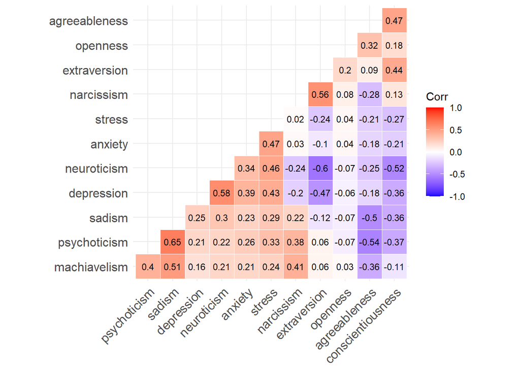

```r
# odabir
traits_vars <- dataset %>%
  select(
    depression, anxiety, stress,
    narcissism, machiavelism, psychoticism, sadism,
    neuroticism, extraversion, openness, agreeableness, conscientiousness
  )

# korelacijska matrica
corr_mat <- cor(traits_vars, use = "pairwise.complete.obs")

# korelacijska heatmapa
ggcorrplot(
  corr_mat,
  type = "lower",
  lab = TRUE,
  lab_size = 3,
  hc.order = TRUE,
  outline.col = "white"
)
```

Osobe s većom anksioznošću, depresijom i stresom imaju tendenciju biti i više neurotične.

Mračne osobine su međusobno umjereno povezane.

Visoka savjesnost štiti od depresije i stresa (negativna korelacija).

Ugodnost je snažno suprotna psihoticizmu i sadizmu.

Big Five su međusobno slabo do umjereno povezane.

# Jesu li ljudi s izraženijom mračnom trijadom skloniji depresiji?

## Upoznavanje podataka

Po analizi podataka već odrađenoj u uvodu znamo da radimo s numeričkim podacima, te da je za ispitivanje povezanosti osobina mračne trijade i depresije prikladno raditi linearnu regresiju. Dakle, nezavisne varijable ovdje su: narcizam, makijavelizam i psihoticizam, a zavisna varijabla je depresija.

```r
describe(data_clean %>%
  select(depression, narcissism, machiavelism, psychoticism))
```

|  | vars | n | mean | sd | median | trimmed | mad | min | max | range | skew | kurtosis | se |
| --- | --- | --- | --- | --- | --- | --- | --- | --- | --- | --- | --- | --- | --- |
| depression | 1 | 398 | 0.03610761 | 1.104274 | -0.14122059 | -0.03516366 | 0.9635133 | -3.071895 | 3.627776 | 6.699672 | 0.6333924 | 0.4765170 | 0.05535226 |
| narcissism | 2 | 398 | -0.07741368 | 1.074633 | 0.02198609 | -0.05273490 | 1.1629150 | -2.600404 | 2.653734 | 5.254139 | -0.1637723 | -0.6343399 | 0.05386649 |
| machiavelism | 3 | 398 | -0.05101746 | 1.084437 | 0.05405943 | -0.00297567 | 1.0926186 | -2.908024 | 2.394374 | 5.302398 | -0.3657739 | -0.4096198 | 0.05435790 |
| psychoticism | 4 | 398 | -0.08198847 | 1.000806 | -0.20454953 | -0.14008376 | 1.0428478 | -2.000840 | 2.991426 | 4.992266 | 0.4776935 | -0.4790861 | 0.05016586 |

## Jednostavna linearna regresija

Kako bismo analizirali zaseban utjecaj svake od ovih varijabli, procijenit ćemo jednostavne regresijske modele, pri čemu će se za svaku nezavisnu varijablu izgraditi poseban model.

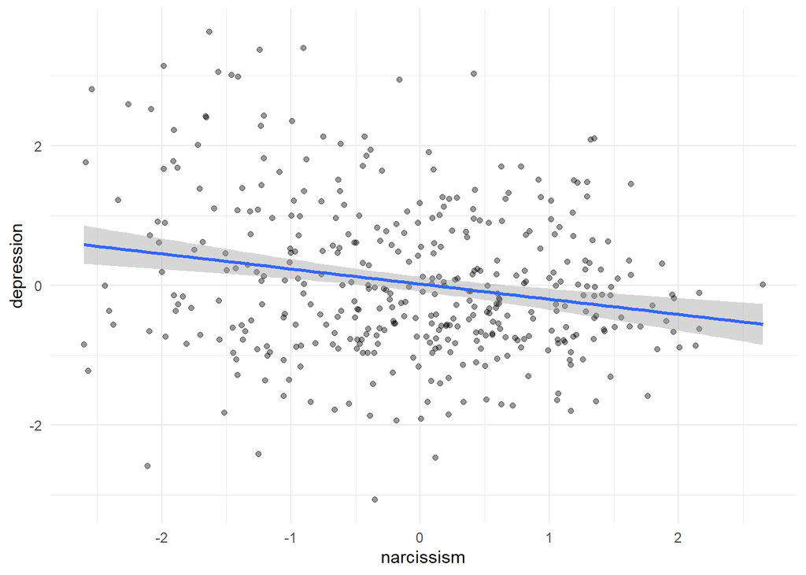

```r
ggplot(data_clean, aes(narcissism, depression)) +
  geom_point(alpha = 0.4) +
  geom_smooth(method = "lm", se = TRUE) +
  theme_minimal()
```

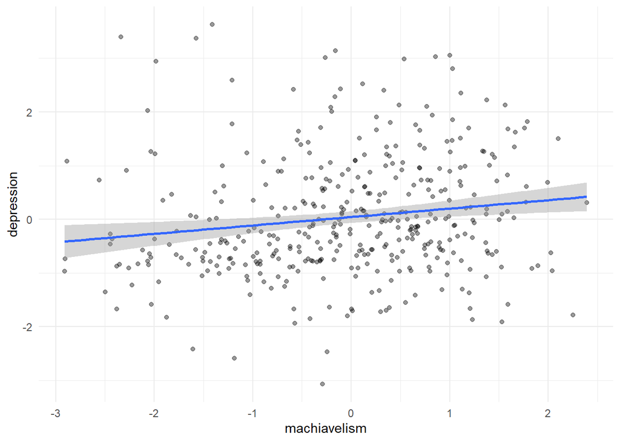

```r
ggplot(data_clean, aes(machiavelism, depression)) +
  geom_point(alpha = 0.4) +
  geom_smooth(method = "lm", se = TRUE) +
  theme_minimal()
```

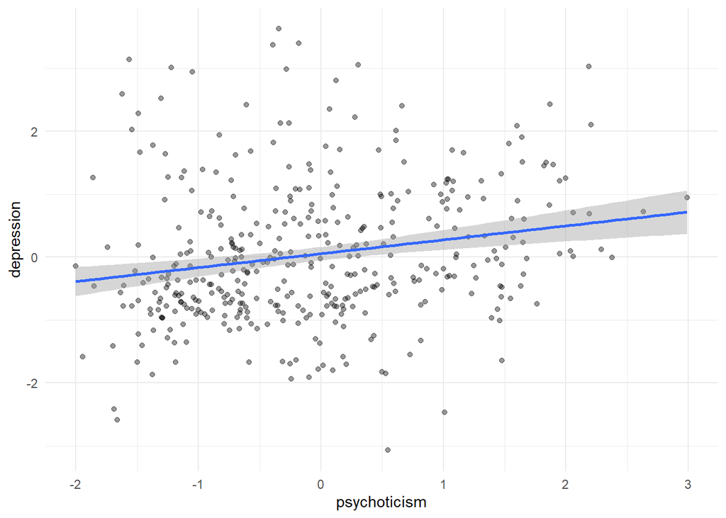

```r
ggplot(data_clean, aes(psychoticism, depression)) +
  geom_point(alpha = 0.4) +
  geom_smooth(method = "lm", se = TRUE) +
  theme_minimal()
```

Nagibi pravaca služe kao potvrda utjecaja pojedine nezavisne varijable na varijablu depresija. Model narcizma jedini ima negativan nagib, ukazujući na negativan utjecaj, dok psihoticizam i makijavelizam imaju pozitivan učinak.

## Pearsonove korelacije

```r
cor.test(data_clean$depression, data_clean$narcissism)
```

```
##
##  Pearson's product-moment correlation
##
## data:  data_clean$depression and data_clean$narcissism
## t = -4.2976, df = 396, p-value = 2.176e-05
## alternative hypothesis: true correlation is not equal to 0
## 95 percent confidence interval:
##  -0.3031034 -0.1151869
## sample estimates:
##        cor
## -0.2110948
```

```r
cor.test(data_clean$depression, data_clean$machiavelism)
```

```
##
##  Pearson's product-moment correlation
##
## data:  data_clean$depression and data_clean$machiavelism
## t = 3.1025, df = 396, p-value = 0.002057
## alternative hypothesis: true correlation is not equal to 0
## 95 percent confidence interval:
##  0.05660396 0.24857887
## sample estimates:
##       cor
## 0.1540449
```

```r
cor.test(data_clean$depression, data_clean$psychoticism)
```

```
##
##  Pearson's product-moment correlation
##
## data:  data_clean$depression and data_clean$psychoticism
## t = 4.0662, df = 396, p-value = 5.767e-05
## alternative hypothesis: true correlation is not equal to 0
## 95 percent confidence interval:
##  0.1039454 0.2927352
## sample estimates:
##       cor
## 0.2001979
```

Pearsonovom korelacijskom analizom utvrđena je statistički značajna negativna povezanost između narcizma i depresije (r = −0.21, p < 0.001). Makijavelizam (r = 0.15, p = 0.002) i psihoticizam (r = 0.20, p < 0.001) pokazali su statistički značajnu pozitivnu povezanost s depresijom. Veličine učinaka su male do umjerene.

Ovo se može prikazati i matrično:

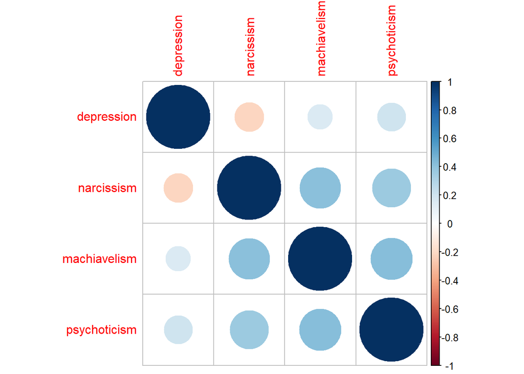

```r
vars1 <- data_clean %>%
  select(depression, narcissism, machiavelism, psychoticism) %>%
  na.omit()

corrplot(cor(vars1))
```

Među prediktorima su prisutne umjerene pozitivne korelacije, no nijedna ne upućuje na problematičnu multikolinearnost. Ovo ćemo još formalno analizirat koristeći, ponovno, Pearsonove korelacije.

```r
cor.test(data_clean$machiavelism, data_clean$narcissism)
```

```
##
##  Pearson's product-moment correlation
##
## data:  data_clean$machiavelism and data_clean$narcissism
## t = 8.961, df = 396, p-value < 2.2e-16
## alternative hypothesis: true correlation is not equal to 0
## 95 percent confidence interval:
##  0.3254326 0.4891514
## sample estimates:
##       cor
## 0.4105959
```

```r
cor.test(data_clean$machiavelism, data_clean$psychoticism)
```

```
##
##  Pearson's product-moment correlation
##
## data:  data_clean$machiavelism and data_clean$psychoticism
## t = 9.3422, df = 396, p-value < 2.2e-16
## alternative hypothesis: true correlation is not equal to 0
## 95 percent confidence interval:
##  0.3409053 0.5022790
## sample estimates:
##       cor
## 0.4249627
```

```r
cor.test(data_clean$narcissism, data_clean$machiavelism)
```

```
##
##  Pearson's product-moment correlation
##
## data:  data_clean$narcissism and data_clean$machiavelism
## t = 8.961, df = 396, p-value < 2.2e-16
## alternative hypothesis: true correlation is not equal to 0
## 95 percent confidence interval:
##  0.3254326 0.4891514
## sample estimates:
##       cor
## 0.4105959
```

```r
cor.test(data_clean$narcissism, data_clean$psychoticism)
```

```
##
##  Pearson's product-moment correlation
##
## data:  data_clean$narcissism and data_clean$psychoticism
## t = 7.8298, df = 396, p-value = 4.519e-14
## alternative hypothesis: true correlation is not equal to 0
## 95 percent confidence interval:
##  0.2778423 0.4483037
## sample estimates:
##       cor
## 0.3661405
```

```r
cor.test(data_clean$psychoticism, data_clean$narcissism)
```

```
##
##  Pearson's product-moment correlation
##
## data:  data_clean$psychoticism and data_clean$narcissism
## t = 7.8298, df = 396, p-value = 4.519e-14
## alternative hypothesis: true correlation is not equal to 0
## 95 percent confidence interval:
##  0.2778423 0.4483037
## sample estimates:
##       cor
## 0.3661405
```

```r
cor.test(data_clean$psychoticism, data_clean$machiavelism)
```

```
##
##  Pearson's product-moment correlation
##
## data:  data_clean$psychoticism and data_clean$machiavelism
## t = 9.3422, df = 396, p-value < 2.2e-16
## alternative hypothesis: true correlation is not equal to 0
## 95 percent confidence interval:
##  0.3409053 0.5022790
## sample estimates:
##       cor
## 0.4249627
```

Pearsonove korelacije između nezavisnih varijabli pokazale su umjerene pozitivne povezanosti između makijavelizma, narcizma i psihoticizma (r ≈ 0,36–0,42, p < 0,001). Iako su ove osobine povezane, snaga korelacija ne sugerira problematičnu multikolinearnost, što podupire njihovo uključivanje kao zasebnih prediktora u regresijski model.

## Višestruka linearna regresija

Sada možemo definirati model višestruke linearne regresije, gdje gledamo sveukupni utjecaj mračne trijade na depresiju.

```r
model_dark_triad <- lm(depression ~ narcissism + machiavelism + psychoticism,
             data = data_clean)

summary(model_dark_triad)
```

```
##
## Call:
## lm(formula = depression ~ narcissism + machiavelism + psychoticism,
##     data = data_clean)
##
## Residuals:
##     Min      1Q  Median      3Q     Max
## -3.3437 -0.6086 -0.1376  0.5302  3.5540
##
## Coefficients:
##              Estimate Std. Error t value Pr(>|t|)
## (Intercept)   0.03894    0.05100   0.763 0.445638
## narcissism   -0.39957    0.05334  -7.490 4.55e-13 ***
## machiavelism  0.20893    0.05434   3.845 0.000141 ***
## psychoticism  0.28178    0.05770   4.884 1.52e-06 ***
## ---
## Signif. codes:  0 '***' 0.001 '**' 0.01 '*' 0.05 '.' 0.1 ' ' 1
##
## Residual standard error: 1.013 on 394 degrees of freedom
## Multiple R-squared:  0.1648, Adjusted R-squared:  0.1585
## F-statistic: 25.92 on 3 and 394 DF,  p-value: 2.545e-15
```

Rezultati reiteriraju prijašnje zaključke da je narcisizam negativno značajan prediktor depresije (b = −0.40, p < 0.001), dok su makiavelizam (b = 0.21, p < 0.001) i psihoticizam (b = 0.28, p < 0.001) pozitivno značajni prediktori. Model je statistički značajan (F-stat = 25.92, p < 0.001). Međutim, ukupna prediktivna snaga modela je umjerena (R² oko 0.16), što sugerira da postoje i drugi faktori koji utječu na depresiju.

Kako bismo provjerili postoje li drugi, prikladniji i značajniji, prediktori prikazat ćemo korelacijsku matricu sa ostalim varijablama.

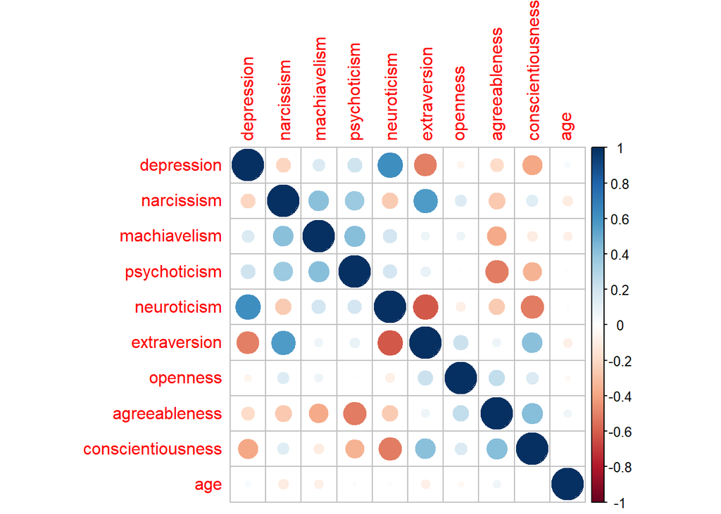

```r
vars2 <- data_clean %>%
  select(depression, narcissism, machiavelism, psychoticism,
               neuroticism, extraversion, openness,
               agreeableness, conscientiousness,
               age) %>%
  na.omit()

corrplot(cor(vars2))
```

Tu su vidljive pozitivne povezanosti depresije s neuroticizmom, psihoticizmom i najmanje makijavelizmom. S druge strane, negativnu korelaciju s depresijom imaju narcizam, ekstraverzija i savjesnost, nešto manje kod ugodnosti. Najjače povezanosti su sa ekstraverzijom i neuroticizmom, koji su međusobno negativno korelirani.

```r
model_2 <- lm(depression ~ narcissism + extraversion + neuroticism + conscientiousness + agreeableness + psychoticism,
             data = data_clean)

summary(model_2)
```

```
##
## Call:
## lm(formula = depression ~ narcissism + extraversion + neuroticism +
##     conscientiousness + agreeableness + psychoticism, data = data_clean)
##
## Residuals:
##     Min      1Q  Median      3Q     Max
## -3.0698 -0.4943  0.0391  0.4561  2.9942
##
## Coefficients:
##                    Estimate Std. Error t value Pr(>|t|)
## (Intercept)        0.017541   0.042738   0.410  0.68172
## narcissism        -0.007888   0.053502  -0.147  0.88287
## extraversion      -0.238504   0.060134  -3.966 8.68e-05 ***
## neuroticism        0.456224   0.055935   8.156 4.76e-15 ***
## conscientiousness -0.030049   0.055976  -0.537  0.59170
## agreeableness      0.038033   0.052069   0.730  0.46556
## psychoticism       0.169456   0.054041   3.136  0.00184 **
## ---
## Signif. codes:  0 '***' 0.001 '**' 0.01 '*' 0.05 '.' 0.1 ' ' 1
##
## Residual standard error: 0.8458 on 391 degrees of freedom
## Multiple R-squared:  0.4222, Adjusted R-squared:  0.4133
## F-statistic: 47.61 on 6 and 391 DF,  p-value: < 2.2e-16
```

Model značajno predviđa depresiju (R² = 0.42, p < 0.001). Neuroticizam je bio najsnažniji pozitivni prediktor depresije (b = 0.46, p < 0.001), dok je ekstraverzija imala značajan negativan učinak (b = −0.24, p < 0.001). Psihoticizam je također pokazao umjeren, ali značajan pozitivan doprinos (b = 0.17, p = 0.0018). Narcizam, savjesnost i ugodnost nisu bili statistički značajni prediktori (p > 0.05), što upućuje na to da njihov odnos s depresijom nije jedinstven nakon kontrole ostalih osobina.

Još ćemo provjeriti predstavlja li kolinearnost značajki problem za ovu interpretaciju:

```r
vif <- function(model) {
  X <- model.matrix(model)[, -1]
  vif_values <- sapply(1:ncol(X), function(i) {
    lm_fit <- lm(X[, i] ~ X[, -i])
    1 / (1 - summary(lm_fit)$r.squared)
  })
  names(vif_values) <- colnames(X)
  return(vif_values)
}

vif(model_2)
```

```
##        narcissism      extraversion       neuroticism conscientiousness
##          1.834314          2.376552          1.930409          1.706299
##     agreeableness      psychoticism
##          1.598789          1.623147
```

VIF faktori za sve prediktore manji su od 5, što ukazuje da ne postoji značajna multikolinearnost među varijablama.

### Provjera pretpostavki linearnih regresija

Još je preostalo provjeriti prate li reziduali ovih modela normalnu distribuciju.

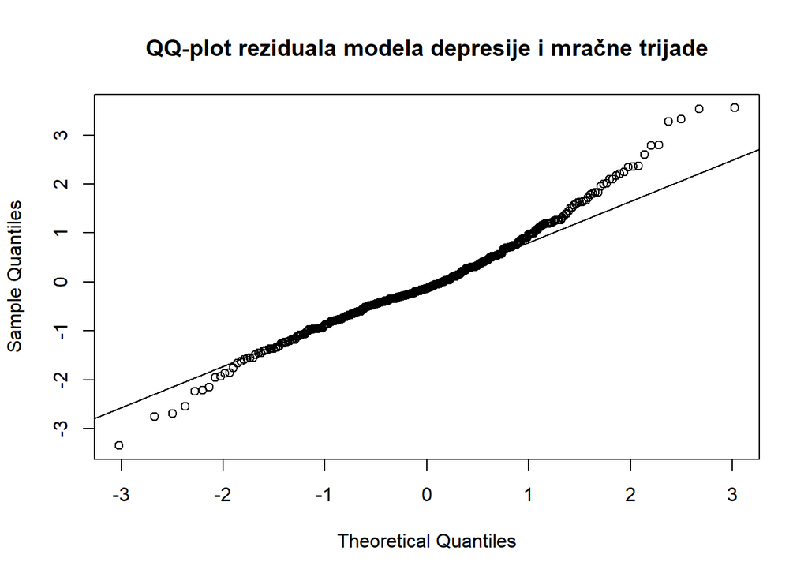

```r
qqnorm(
  residuals(model_dark_triad),
  main = "QQ-plot reziduala modela depresije i mračne trijade"
)
qqline(residuals(model_dark_triad))
```

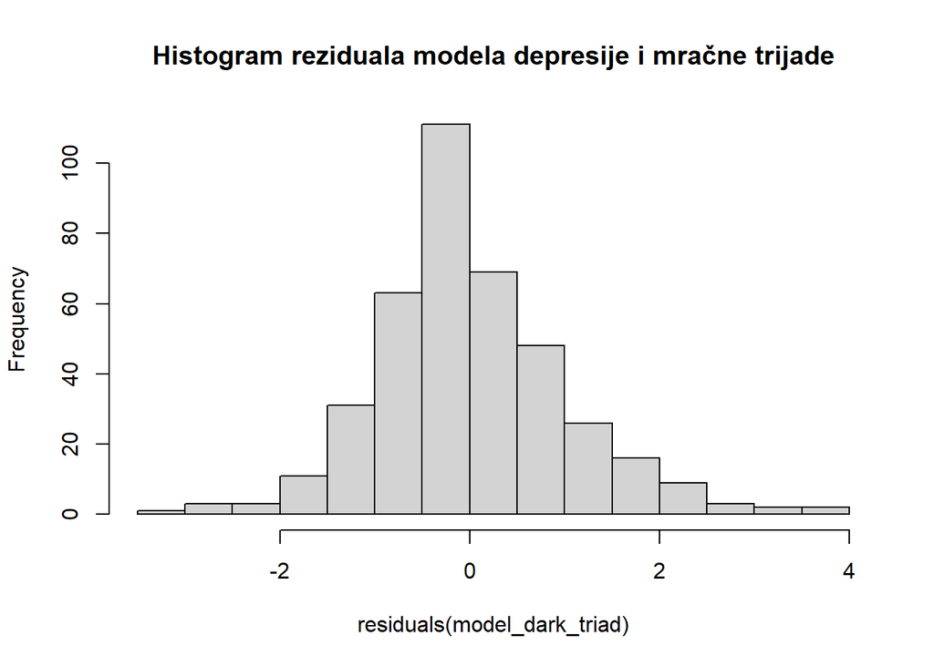

```r
hist(residuals(model_dark_triad), breaks = 20, main = "Histogram reziduala modela depresije i mračne trijade")
```

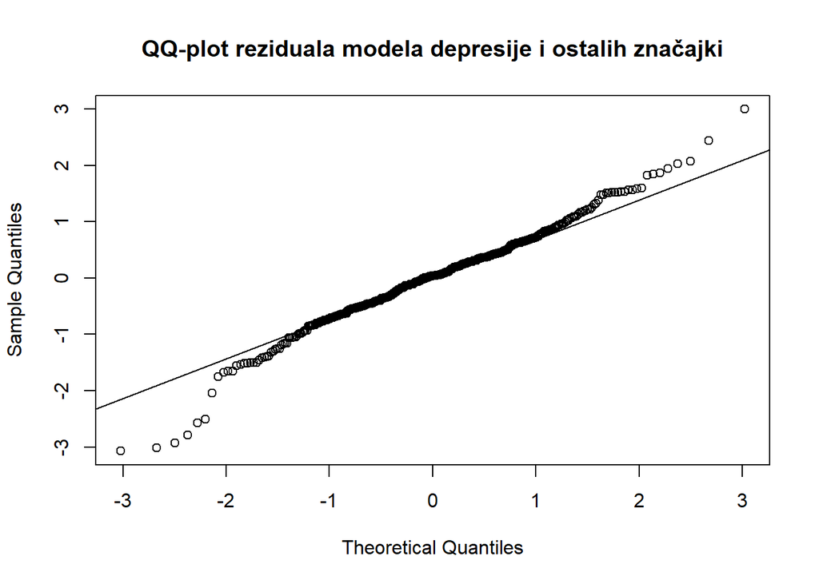

```r
qqnorm(
  residuals(model_2),
  main = "QQ-plot reziduala modela depresije i ostalih značajki"
)
qqline(residuals(model_2))
```

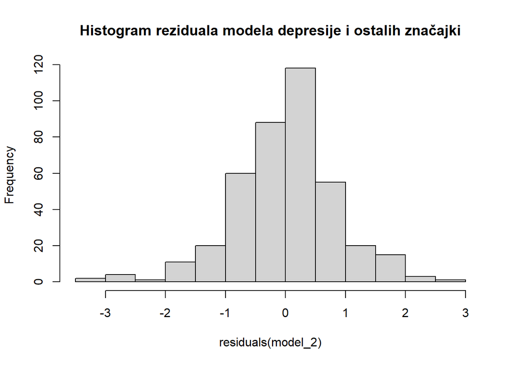

```r
hist(residuals(model_2), breaks = 20, main = "Histogram reziduala modela depresije i ostalih značajki")
```

Normalnost reziduala provjerena je pomoću QQ-plota i histograma, koji su pokazali približno normalnu distribuciju, uz manja odstupanja na krajevima distribucije. Odstupanja su zastupljenija kod drugog modela koji ne uključuje samo varijable mračne trijade, već i ostale značajke.

## Zaključak

Pokazali smo da osobine koje čine mračnu trijadu: psihoticizam, makijavelizam i narcizam, same po sebi utječu na depresiju, ali njihov učinak nije jednako snažan kao učinak nekih drugih osobina, poput niske ekstraverzije i visokog neuroticizma s elementima psihoticizma.

# Postoje li razlike u nekim crtama ličnosti među spolovima?

```r
table(data_clean$sex)
```

```
##
##            Female              Male Prefer not to say
##               186               209                 3
```

```r
df_sex <- data_clean %>%
  filter(sex %in% c("Male", "Female"))
```

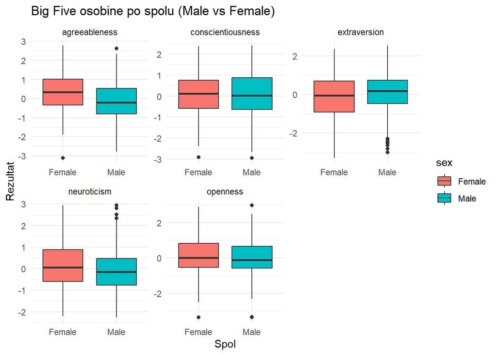

```r
big_five <- df_sex %>%
  pivot_longer(
    cols = c(neuroticism, extraversion, openness, agreeableness, conscientiousness),
    names_to = "trait",
    values_to = "score"
  )

ggplot(big_five, aes(x = sex, y = score, fill = sex)) +
  geom_boxplot() +
  facet_wrap(~ trait, scales = "free") +
  theme_minimal() +
  labs(
    title = "Big Five osobine po spolu (Male vs Female)",
    x = "Spol",
    y = "Rezultat"
  )
```

Vizualna analiza boxplotova ukazuje na obrasce razlika između spolova koji su u skladu s teorijskim očekivanjima. Najizraženije razlike uočavaju se kod neuroticizma i ugodnosti, pri čemu žene u prosjeku postižu više vrijednosti, što je vidljivo kroz više medijane i pomak distribucije prema višim vrijednostima.

Kod ekstraverzije, otvorenosti i savjesnosti razlike između spolova su manje izražene; medijani su vrlo slični, a distribucije se u velikoj mjeri preklapaju, što upućuje na izostanak izraženih spolnih razlika u tim osobinama na razini deskriptivne analize.

Prije provedbe t-testa za nezavisne uzorke, potrebno je provjeriti jesu li zadovoljene osnovne pretpostavke testa, uključujući normalnost distribucije, homogenost varijanci te nezavisnost uzoraka.

Za početak ćemo provjeriti preptpostavku o normalnosti uzorka.

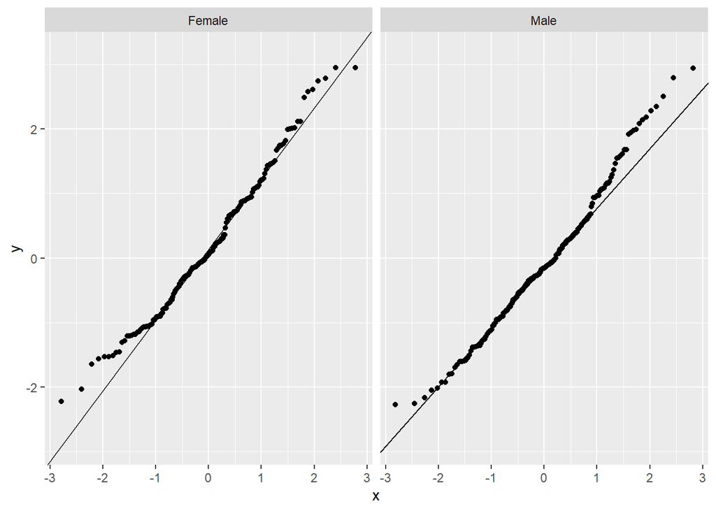

```r
ggplot(df_sex, aes(sample = neuroticism)) +
  stat_qq() + stat_qq_line() +
  facet_wrap(~sex)
```

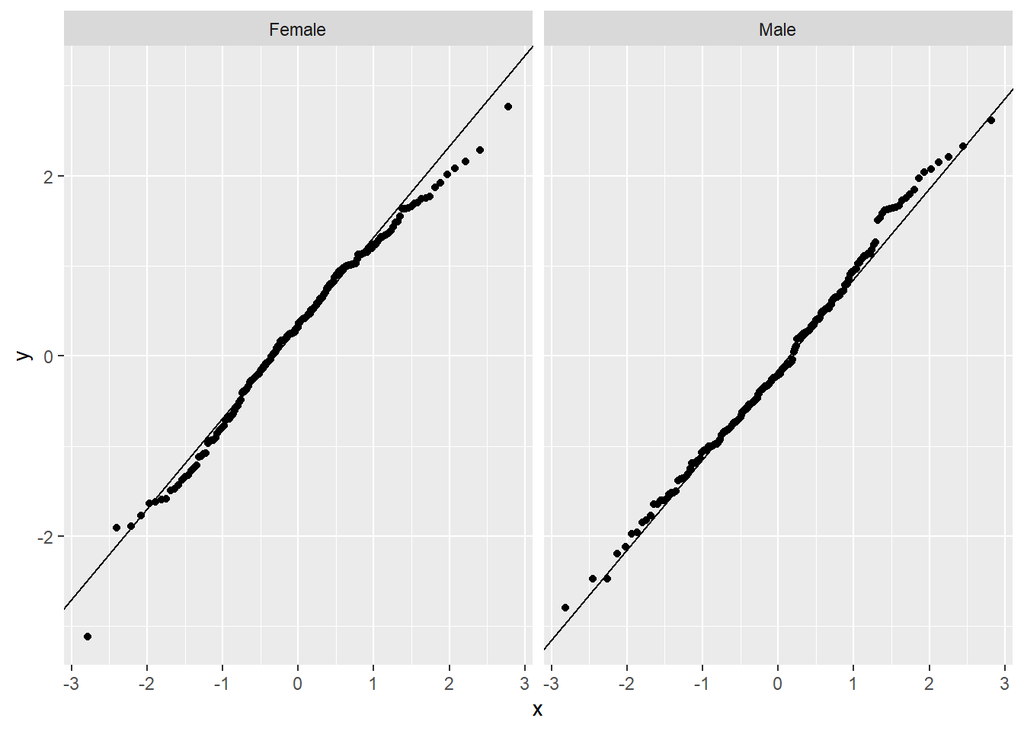

```r
ggplot(df_sex, aes(sample = agreeableness)) +
  stat_qq() + stat_qq_line() +
  facet_wrap(~sex)
```

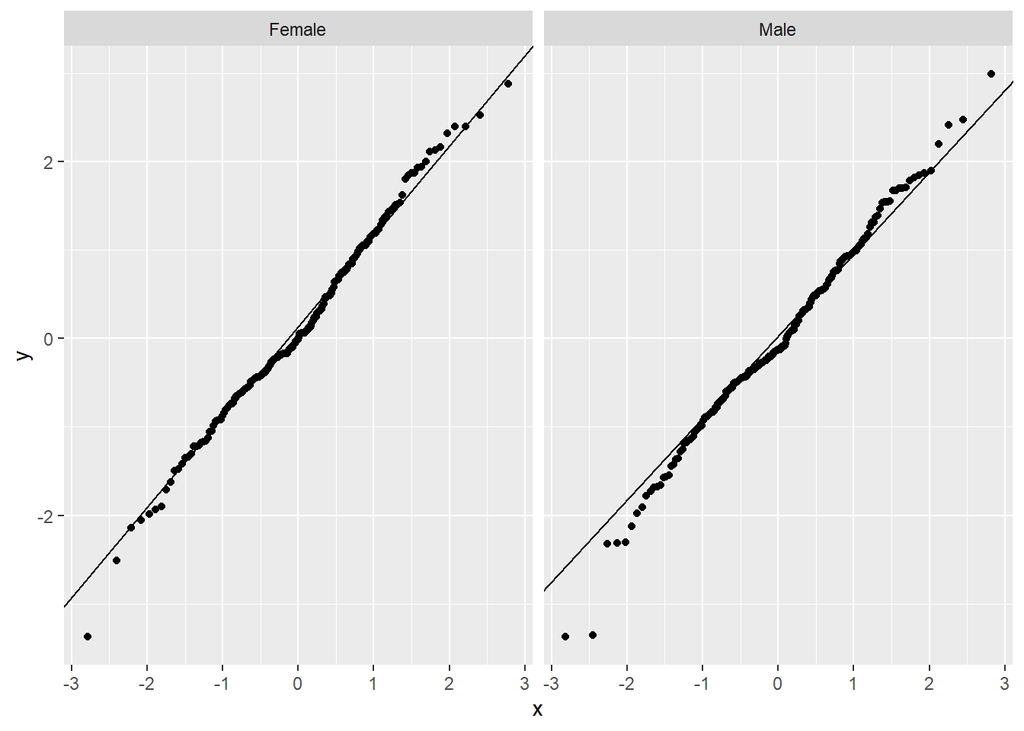

```r
ggplot(df_sex, aes(sample = openness)) +
  stat_qq() + stat_qq_line() +
  facet_wrap(~sex)
```

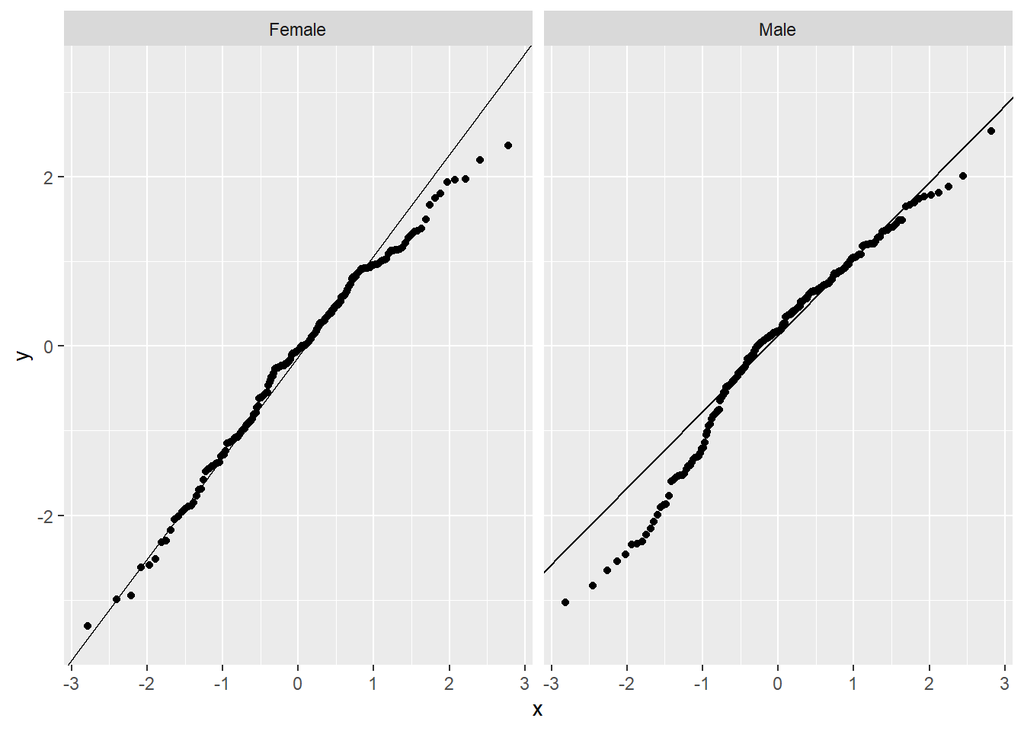

```r
ggplot(df_sex, aes(sample = extraversion)) +
  stat_qq() + stat_qq_line() +
  facet_wrap(~sex)
```

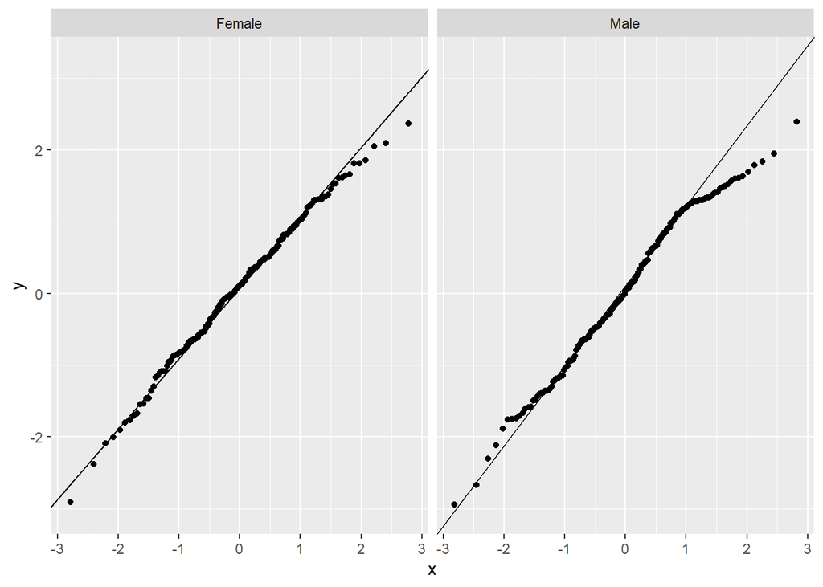

```r
ggplot(df_sex, aes(sample = conscientiousness)) +
  stat_qq() + stat_qq_line() +
  facet_wrap(~sex)
```

Distribucije u skupinama su priližno normalne. Zatim ćemo provjeriti varijance.

```r
traits <- c("neuroticism", "agreeableness", "openness", "extraversion", "conscientiousness")

var_by_sex <- df_sex %>%
  group_by(sex) %>%
  summarise(across(all_of(traits), ~ var(.x, na.rm = TRUE)))

var_by_sex
```

| sex | neuroticism | agreeableness | openness | extraversion | conscientiousness |
| --- | --- | --- | --- | --- | --- |
| Female | 1.110821 | 0.9770427 | 1.125490 | 1.225519 | 0.8972597 |
| Male | 1.059667 | 1.0665122 | 1.076125 | 1.138915 | 1.0253118 |

```r
var_tests <- lapply(traits, function(tr) {
  f <- as.formula(paste(tr, "~ sex"))
  vt <- var.test(f, data = df_sex)
  tibble(
    trait = tr,
    F_statistic = round(vt$statistic, 3),
    p_value = round(vt$p.value, 4)
  )
})

bind_rows(var_tests)
```

| trait | F_statistic | p_value |
| --- | --- | --- |
| neuroticism | 1.048 | 0.7396 |
| agreeableness | 0.916 | 0.5426 |
| openness | 1.046 | 0.7517 |
| extraversion | 1.076 | 0.6064 |
| conscientiousness | 0.875 | 0.3535 |

Rezultati testa za jednakost varijanci pokazuju da ni za jednu od analiziranih osobina ličnosti nije utvrđena statistički značajna razlika u varijancama između muškaraca i žena. Sve dobivene p-vrijednosti veće su od 0.05, stoga se u svim slučajevima ne odbacuje nul-hipoteza o jednakosti varijanci.

Dodatno, promatramo dvije nezavisne skupine: Female i Male (ostale ćemo ukloniti).

Stoga, sve pretpostavke su zadovoljene i provest ćemo t-test za nezavisne uzorke.

```r
# t-test za svaku osobinu
results <- lapply(traits, function(tr) {
  formula <- as.formula(paste(tr, "~ sex")) #npr. neuroticism ~ sex
  test <- t.test(formula, data = df_sex)
  print(test$estimate)
  tibble(
    trait = tr,#naziv osobine
    t_statistic = round(test$statistic, 3), #t vrijednost
    p_value = round(test$p.value, 5),
    mean_female = round(test$estimate["mean in group Female"], 3),
    mean_male = round(test$estimate["mean in group Male"], 3)
  )
})
```

```
## mean in group Female   mean in group Male
##           0.18251516          -0.08261147
## mean in group Female   mean in group Male
##            0.2738572           -0.1091680
## mean in group Female   mean in group Male
##           0.10694830          -0.02212707
## mean in group Female   mean in group Male
##          -0.14239955           0.04568951
## mean in group Female   mean in group Male
##           0.07941870           0.03722745
```

```r
results_df <- bind_rows(results)
results_df
```

| trait | t_statistic | p_value | mean_female | mean_male |
| --- | --- | --- | --- | --- |
| neuroticism | 2.523 | 0.01204 | 0.183 | -0.083 |
| agreeableness | 3.764 | 0.00019 | 0.274 | -0.109 |
| openness | 1.220 | 0.22334 | 0.107 | -0.022 |
| extraversion | -1.714 | 0.08728 | -0.142 | 0.046 |
| conscientiousness | 0.428 | 0.66908 | 0.079 | 0.037 |

Rezultati dvostranih t-testova za nezavisne uzorke ukazuju na postojanje statistički značajnih spolnih razlika u pojedinim dimenzijama ličnosti. Žene postižu značajno više prosječne rezultate od muškaraca u neuroticizmu (t = 2.52, p = 0.012) i ugodnosti (t = 3.76, p < 0.001).

Za otvorenost (t = 1.22, p = 0.223), ekstraverziju (t = −1.71, p = 0.087) i savjesnost (t = 0.43, p = 0.669) nisu utvrđene statistički značajne razlike između spolova, iako su uočene blage razlike u prosječnim vrijednostima.

Sad ćemo pogledati mračne osobine.

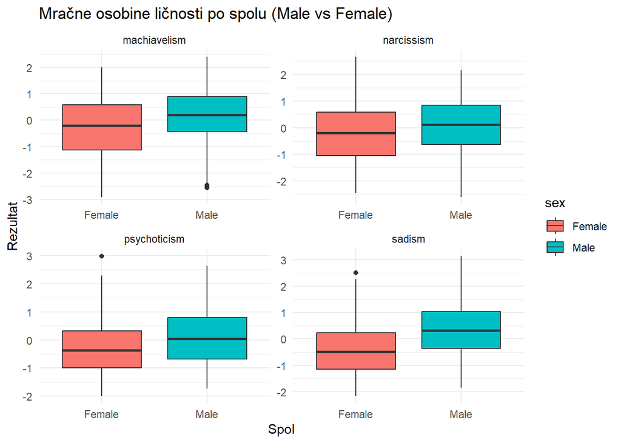

```r
dark_traits <- df_sex %>%
  pivot_longer(
    cols = c(narcissism, machiavelism, psychoticism, sadism),
    names_to = "trait",
    values_to = "score"
  )

ggplot(dark_traits, aes(x = sex, y = score, fill = sex)) +
  geom_boxplot() +
  facet_wrap(~ trait, scales = "free") +
  theme_minimal() +
  labs(
    title = "Mračne osobine ličnosti po spolu (Male vs Female)",
    x = "Spol",
    y = "Rezultat"
  )
```

Vizualna analiza mračnih osobina ličnosti ukazuje na izraženije spolne razlike u odnosu na Big Five osobine. Muškarci u prosjeku postižu više rezultate u makijavelizmu, narcizmu, psihoticizmu i sadizmu, što je vidljivo kroz više medijane i pomak distribucija prema višim vrijednostima. Razlike su posebno izražene kod sadizma i psihoticizma, dok su kod makijavelizma i narcizma prisutne umjerene razlike uz djelomično preklapanje distribucija.

Također, za mračne osobine ličnosti provest ćemo provjeru pretpostavki normalnosti distribucije i jednakosti varijanci. Analiza se temelji na istim dvjema nezavisnim skupinama ispitanik (Female i Male).

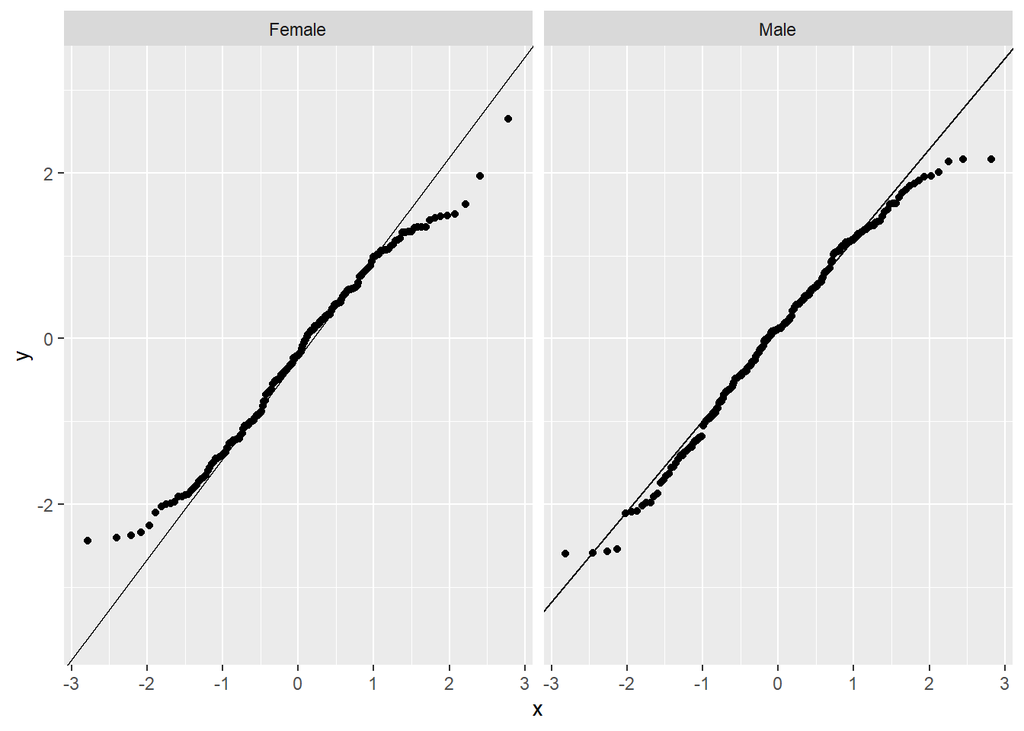

```r
ggplot(df_sex, aes(sample = narcissism)) +
  stat_qq() + stat_qq_line() +
  facet_wrap(~sex)
```

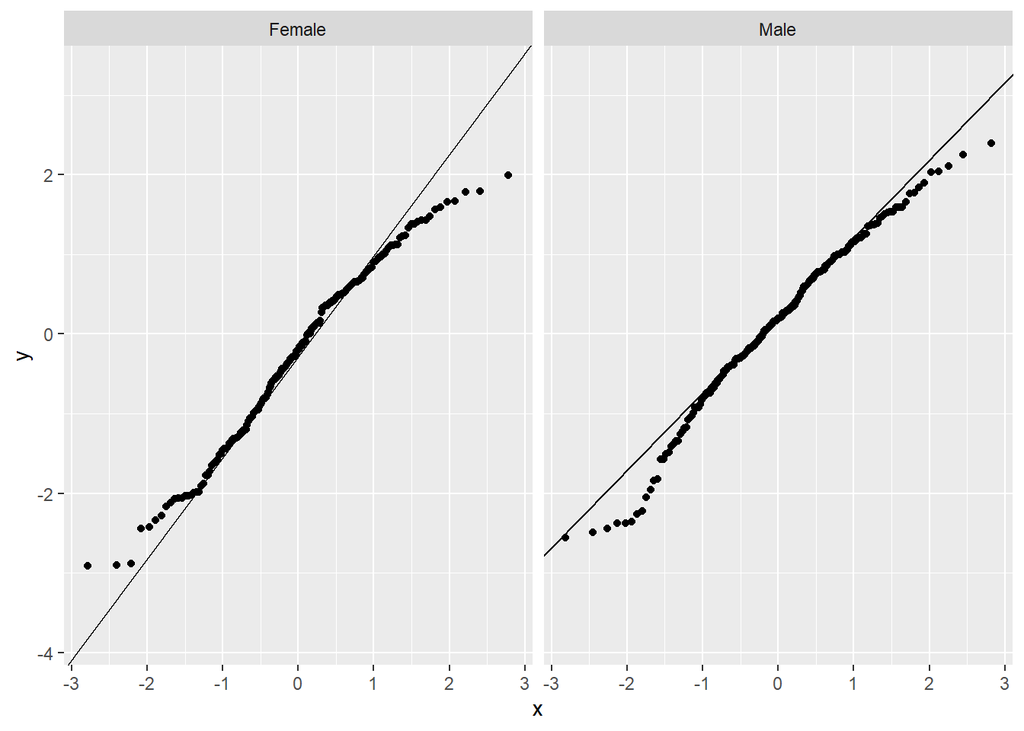

```r
ggplot(df_sex, aes(sample = machiavelism)) +
  stat_qq() + stat_qq_line() +
  facet_wrap(~sex)
```

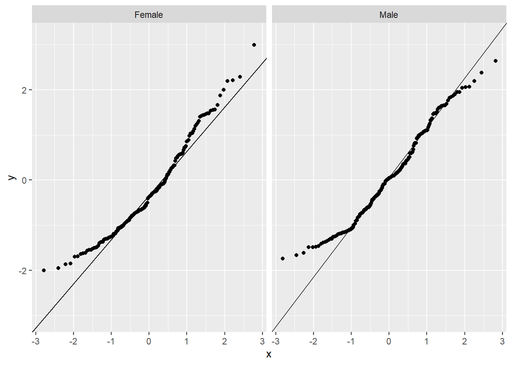

```r
ggplot(df_sex, aes(sample = psychoticism)) +
  stat_qq() + stat_qq_line() +
  facet_wrap(~sex)
```

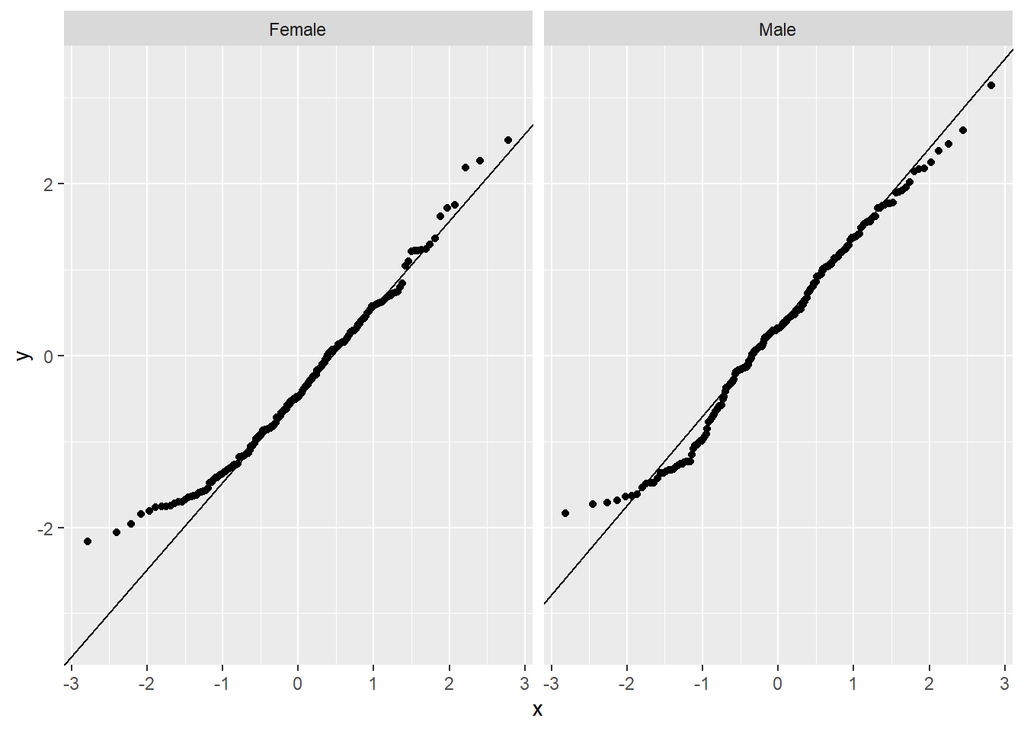

```r
ggplot(df_sex, aes(sample = sadism)) +
  stat_qq() + stat_qq_line() +
  facet_wrap(~sex)
```

Distribucije u skupinama su priližno normalne.

```r
dark <- c("narcissism", "machiavelism", "psychoticism", "sadism")

var_by_sex <- df_sex %>%
  group_by(sex) %>%
  summarise(across(all_of(dark), ~ var(.x, na.rm = TRUE)))

var_by_sex
```

| sex | narcissism | machiavelism | psychoticism | sadism |
| --- | --- | --- | --- | --- |
| Female | 1.116437 | 1.243231 | 0.9811736 | 0.8701965 |
| Male | 1.166037 | 1.052511 | 0.9668707 | 1.0847585 |

```r
var_tests <- lapply(dark, function(tr) {
  f <- as.formula(paste(tr, "~ sex"))
  vt <- var.test(f, data = df_sex)
  tibble(
    trait = tr,
    F_statistic = round(vt$statistic, 3),
    p_value = round(vt$p.value, 4)
  )
})

bind_rows(var_tests)
```

| trait | F_statistic | p_value |
| --- | --- | --- |
| narcissism | 0.957 | 0.7635 |
| machiavelism | 1.181 | 0.2429 |
| psychoticism | 1.015 | 0.9160 |
| sadism | 0.802 | 0.1254 |

Varijance mračnih osobina ličnosti između muškaraca i žena su usporedive i približno jednake, stoga je pretpostavka homogenosti varijanci zadovoljena.

Provest ćemo t-test.

```r
dark <- c("narcissism", "machiavelism", "psychoticism", "sadism")

dark_results <- lapply(dark, function(tr) {
  formula <- as.formula(paste(tr, "~ sex"))
  test <- t.test(formula, data = df_sex)
  tibble(
    trait = tr,
    t_statistic = round(test$statistic, 3),
    p_value = round(test$p.value, 5),
    mean_female = round(test$estimate["mean in group Female"], 3),
    mean_male = round(test$estimate["mean in group Male"], 3)
  )
})

dark_results_df <- bind_rows(dark_results)
dark_results_df
```

| trait | t_statistic | p_value | mean_female | mean_male |
| --- | --- | --- | --- | --- |
| narcissism | -2.582 | 0.01019 | -0.221 | 0.057 |
| machiavelism | -3.751 | 0.00020 | -0.270 | 0.136 |
| psychoticism | -3.221 | 0.00138 | -0.251 | 0.069 |
| sadism | -6.796 | 0.00000 | -0.385 | 0.290 |

U analizi mračnih osobina ličnosti pronađene su jasne spolne razlike. Budući da je u t-testu korišten format tr ~ sex, negativne t-vrijednosti ukazuju na više rezultate u skupini muškaraca u odnosu na žene.

Rezultati pokazuju da muškarci postižu statistički značajno više rezultate na svim analiziranim mračnim crtama — narcizmu, makijavelizmu, psihoticizmu i sadizmu (sve p < 0.05). Najizraženija razlika uočena je kod sadizma, gdje muškarci ostvaruju znatno više prosječne vrijednosti u odnosu na žene, što upućuje na izraženije spolne razlike u ovoj dimenziji ličnosti.

```r
df_sex$sex <- factor(df_sex$sex, levels = c("Female", "Male"))
levels(df_sex$sex)
```

```
## [1] "Female" "Male"
```

```r
traits_dark <- c("narcissism", "machiavelism",
                 "psychoticism", "sadism")

results_one_tailed <- lapply(traits_dark, function(tr) {
  f <- as.formula(paste(tr, "~ sex"))
  test <- t.test(f, data = df_sex, alternative = "less")

  tibble(
    trait = tr,
    t_statistic = round(test$statistic, 3),
    p_value = round(test$p.value, 5),
    mean_female = round(test$estimate["mean in group Female"], 3),
    mean_male = round(test$estimate["mean in group Male"], 3)
  )
})

results_one_tailed_df <- bind_rows(results_one_tailed)
results_one_tailed_df
```

| trait | t_statistic | p_value | mean_female | mean_male |
| --- | --- | --- | --- | --- |
| narcissism | -2.582 | 0.00510 | -0.221 | 0.057 |
| machiavelism | -3.751 | 0.00010 | -0.270 | 0.136 |
| psychoticism | -3.221 | 0.00069 | -0.251 | 0.069 |
| sadism | -6.796 | 0.00000 | -0.385 | 0.290 |

Rezultati jednostranog t-testa, provedenog u smjeru teorijske pretpostavke da muškarci postižu više rezultate od žena, potvrđuju postojanje statistički značajnih spolnih razlika u svim analiziranim mračnim osobinama ličnosti. Muškarci ostvaruju značajno više vrijednosti u narcizmu, makijavelizmu, psihoticizmu i sadizmu, pri čemu je razlika najizraženija kod sadizma.

# Jačaju li neke osobine s godinama?

Nezavisna varijabla (prediktori):

–>Dob (age)

Zavisne varijable:

–> Ekstraverzija (extraversion) –> Ugodnost (agreeableness) –> Savjesnost (conscientiousness) –> Neuroticizam (neuroticism) –> Otvorenost (openness)

U nastavku se analiza provodi zasebno za svaku osobinu. Budući da su i dob i crte ličnosti kontinuirane varijable, a istraživačko pitanje se odnosi na linearnu promjenu s godinama, jednostavna linearna regresija predstavlja najprikladniji statistički pristup.

```r
describe(data_clean %>%
  select(age, extraversion, agreeableness,
         conscientiousness, neuroticism, openness))
```

|  | vars | n | mean | sd | median | trimmed | mad | min | max | range | skew | kurtosis | se |
| --- | --- | --- | --- | --- | --- | --- | --- | --- | --- | --- | --- | --- | --- |
| age | 1 | 398 | 31.92211055 | 4.5366088 | 32.00000000 | 31.831250000 | 5.9304000 | 25.000000 | 40.000000 | 15.000000 | 0.11900918 | -1.18377186 | 0.22739965 |
| extraversion | 2 | 398 | -0.04134545 | 1.0883069 | 0.08762386 | 0.018991512 | 1.0525471 | -3.309888 | 2.540486 | 5.850374 | -0.49948003 | -0.10695813 | 0.05455190 |
| agreeableness | 3 | 398 | 0.07245323 | 1.0308927 | 0.10337296 | 0.074593563 | 1.1171974 | -3.118949 | 2.770404 | 5.889354 | -0.06103949 | -0.33346752 | 0.05167398 |
| conscientiousness | 4 | 398 | 0.05095950 | 0.9906549 | 0.06812853 | 0.082272973 | 1.0526548 | -2.943496 | 2.396841 | 5.340337 | -0.25959700 | -0.28082589 | 0.04965704 |
| neuroticism | 5 | 398 | 0.04551331 | 1.0544660 | -0.06986068 | -0.003432935 | 1.0545372 | -2.268353 | 2.946916 | 5.215268 | 0.41155489 | -0.04854708 | 0.05285560 |
| openness | 6 | 398 | 0.04061378 | 1.0462990 | -0.09290403 | 0.037448288 | 0.9540744 | -3.375867 | 2.985590 | 6.361456 | -0.03323812 | 0.32836076 | 0.05244623 |

Deskriptivna statistika pruža osnovni uvid u raspodjelu dobi i razinu pojedinih crta ličnosti u uzorku ispitanika.

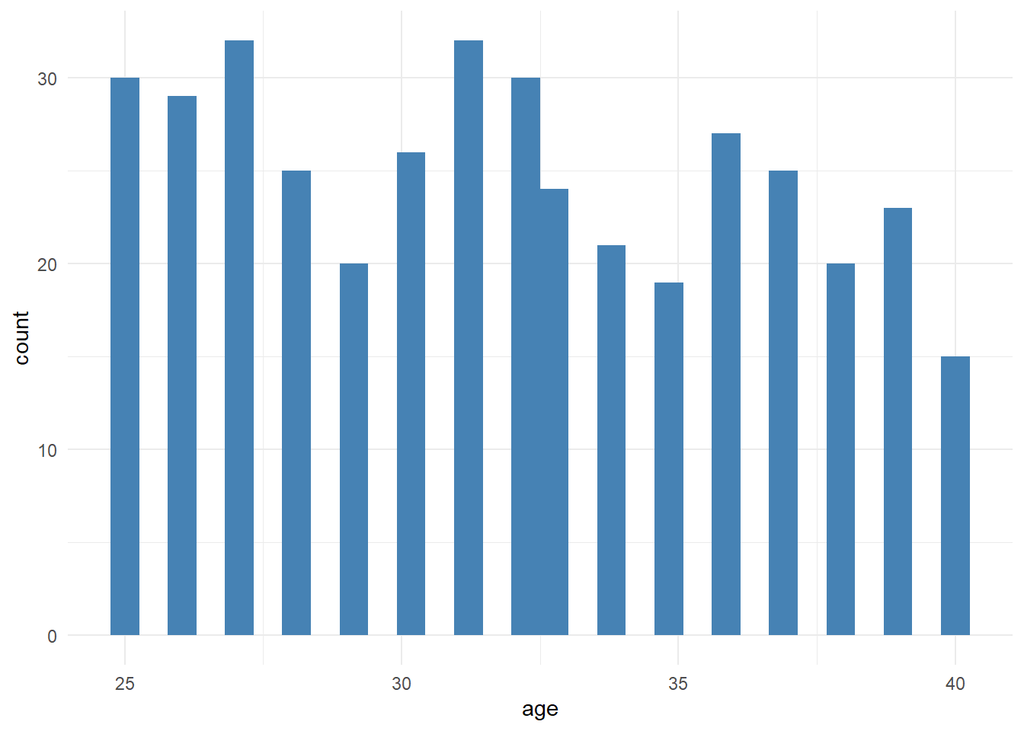

```r
ggplot(data_clean, aes(age)) +
  geom_histogram(bins = 30, fill = "steelblue") +
  theme_minimal()
```

Histogram dobi prikazuje raspodjelu ispitanika po dobnim skupinama te omogućuje procjenu raspona i strukture dobi u uzorku.

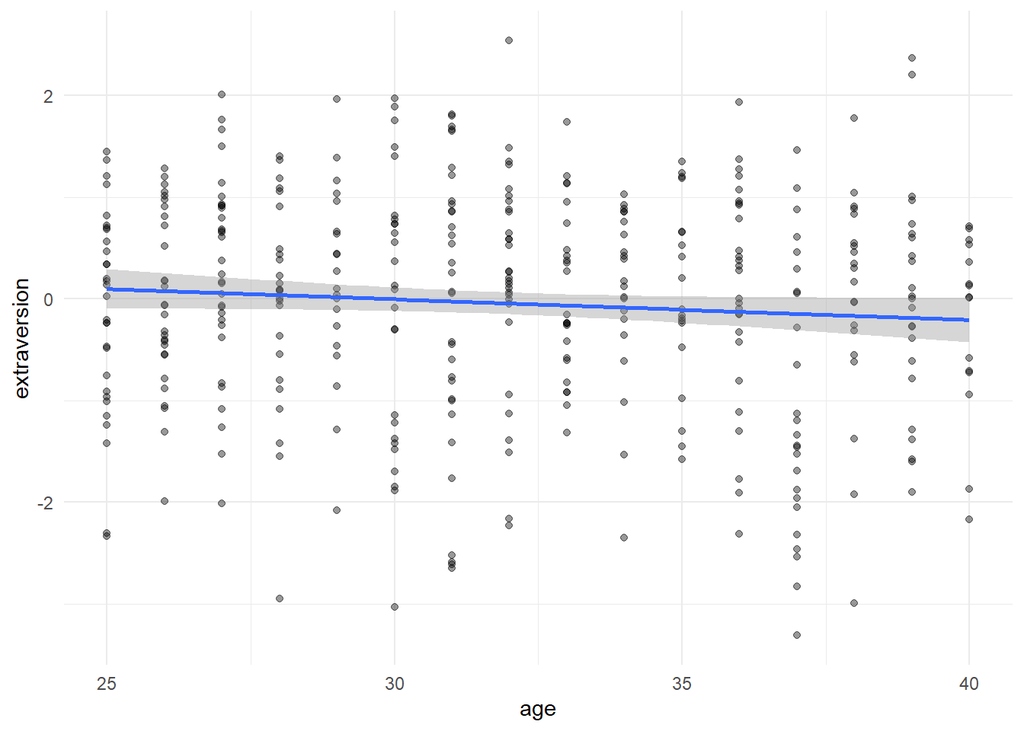

```r
ggplot(data_clean, aes(age, extraversion)) +
  geom_point(alpha = 0.4) +
  geom_smooth(method = "lm", se = TRUE) +
  theme_minimal()
```

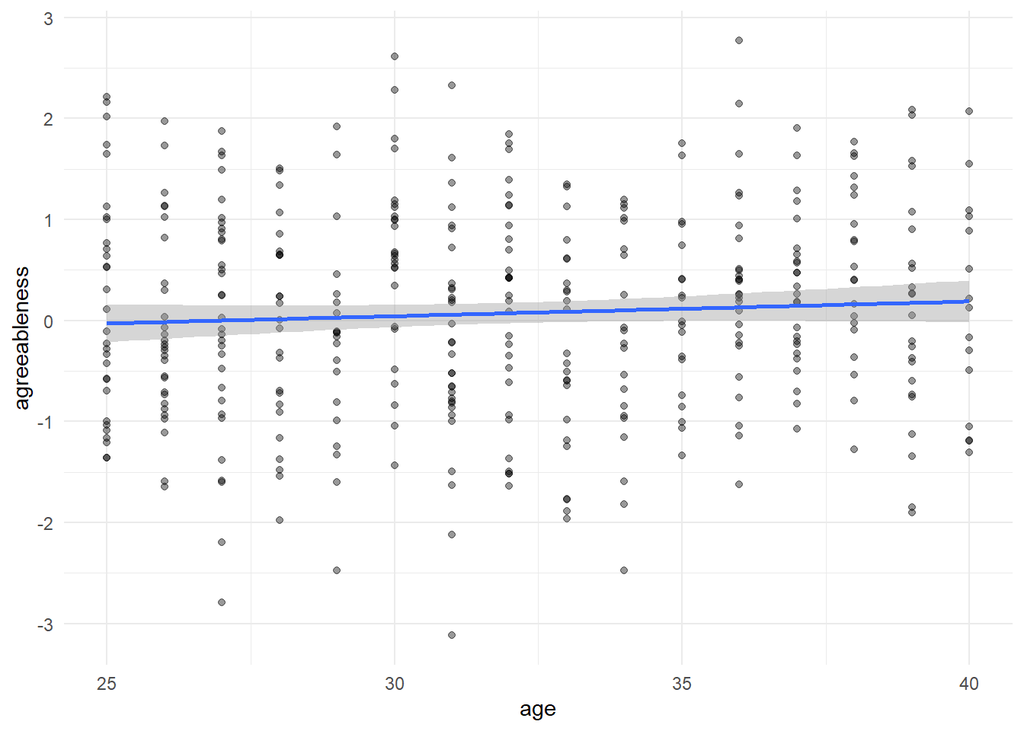

```r
ggplot(data_clean, aes(age, agreeableness)) +
  geom_point(alpha = 0.4) +
  geom_smooth(method = "lm", se = TRUE) +
  theme_minimal()
```

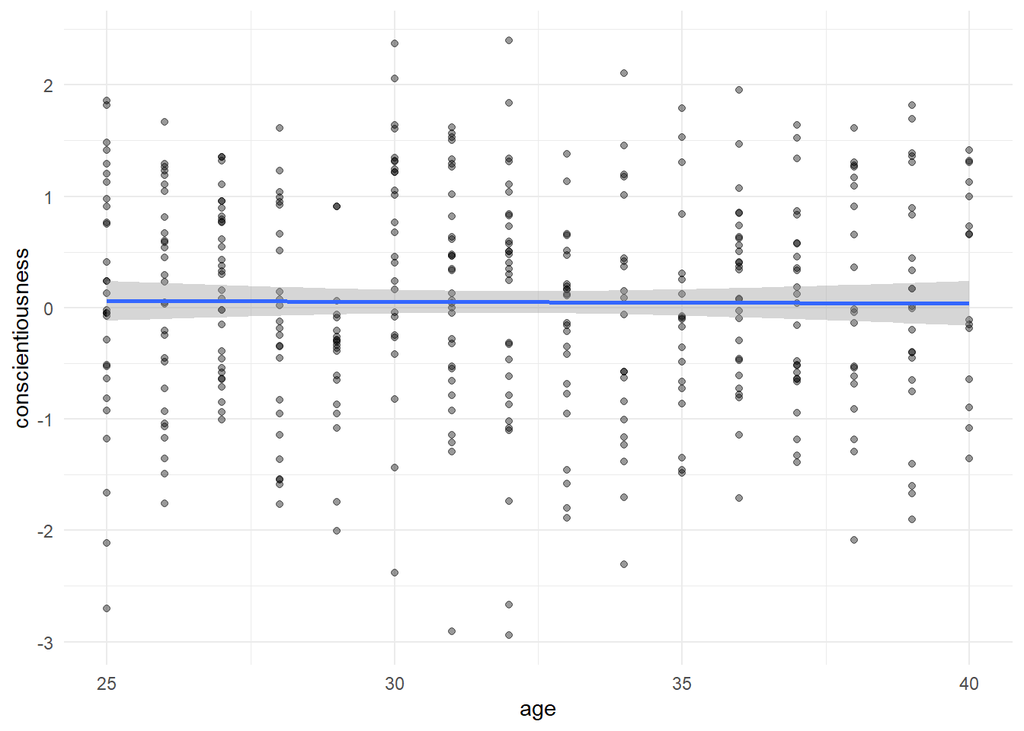

```r
ggplot(data_clean, aes(age, conscientiousness)) +
  geom_point(alpha = 0.4) +
  geom_smooth(method = "lm", se = TRUE) +
  theme_minimal()
```

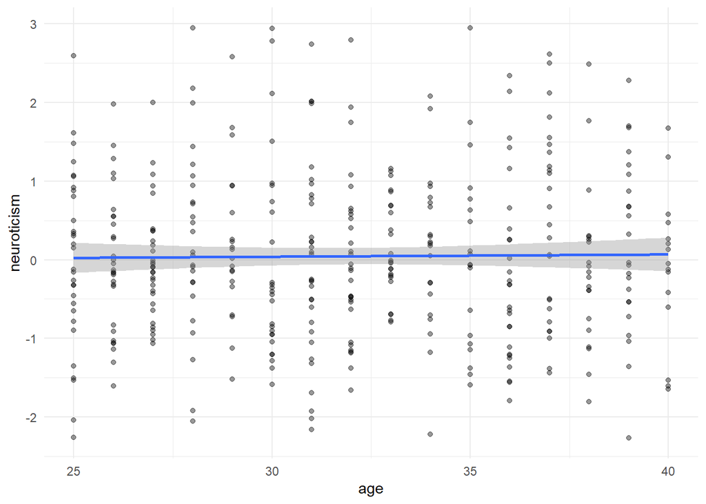

```r
ggplot(data_clean, aes(age, neuroticism)) +
  geom_point(alpha = 0.4) +
  geom_smooth(method = "lm", se = TRUE) +
  theme_minimal()
```

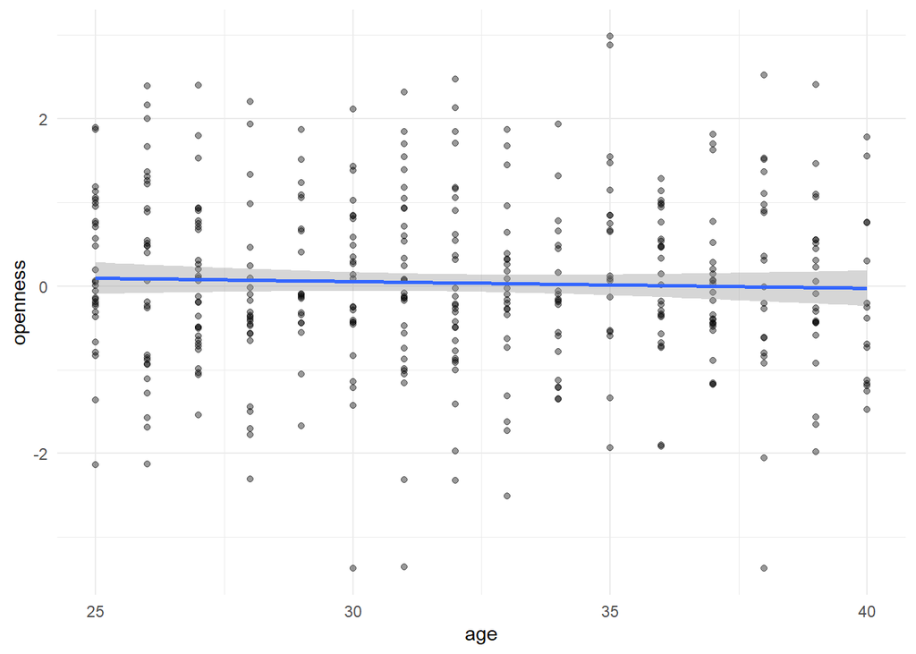

```r
ggplot(data_clean, aes(age, openness)) +
  geom_point(alpha = 0.4) +
  geom_smooth(method = "lm", se = TRUE) +
  theme_minimal()
```

Raspršeni dijagrami s pripadajućim regresijskim linijama korišteni su za vizualnu procjenu linearnog odnosa između dobi i pojedinih crta ličnosti. Grafički prikazi ne upućuju na izražene linearne trendove, iako se kod nekih osobina može uočiti blagi rast ili pad vrijednosti s porastom dobi.

```r
cor.test(data_clean$age, data_clean$extraversion)
```

```
##
##  Pearson's product-moment correlation
##
## data:  data_clean$age and data_clean$extraversion
## t = -1.7053, df = 396, p-value = 0.08893
## alternative hypothesis: true correlation is not equal to 0
## 95 percent confidence interval:
##  -0.18215014  0.01302653
## sample estimates:
##         cor
## -0.08538084
```

```r
cor.test(data_clean$age, data_clean$agreeableness)
```

```
##
##  Pearson's product-moment correlation
##
## data:  data_clean$age and data_clean$agreeableness
## t = 1.2789, df = 396, p-value = 0.2017
## alternative hypothesis: true correlation is not equal to 0
## 95 percent confidence interval:
##  -0.0343782  0.1614170
## sample estimates:
##        cor
## 0.06413658
```

```r
cor.test(data_clean$age, data_clean$conscientiousness)
```

```
##
##  Pearson's product-moment correlation
##
## data:  data_clean$age and data_clean$conscientiousness
## t = -0.13972, df = 396, p-value = 0.889
## alternative hypothesis: true correlation is not equal to 0
## 95 percent confidence interval:
##  -0.10524642  0.09134006
## sample estimates:
##          cor
## -0.007021018
```

```r
cor.test(data_clean$age, data_clean$neuroticism)
```

```
##
##  Pearson's product-moment correlation
##
## data:  data_clean$age and data_clean$neuroticism
## t = 0.2454, df = 396, p-value = 0.8063
## alternative hypothesis: true correlation is not equal to 0
## 95 percent confidence interval:
##  -0.08607148  0.11049500
## sample estimates:
##        cor
## 0.01233089
```

```r
cor.test(data_clean$age, data_clean$openness)
```

```
##
##  Pearson's product-moment correlation
##
## data:  data_clean$age and data_clean$openness
## t = -0.69464, df = 396, p-value = 0.4877
## alternative hypothesis: true correlation is not equal to 0
## 95 percent confidence interval:
##  -0.13272862  0.06363051
## sample estimates:
##         cor
## -0.03488574
```

Pearsonove korelacije korištene su kao preliminarna analiza odnosa dobi i crta ličnosti. Rezultati korelacija ne upućuju na statistički značajne povezanosti između dobi i promatranih osobina.

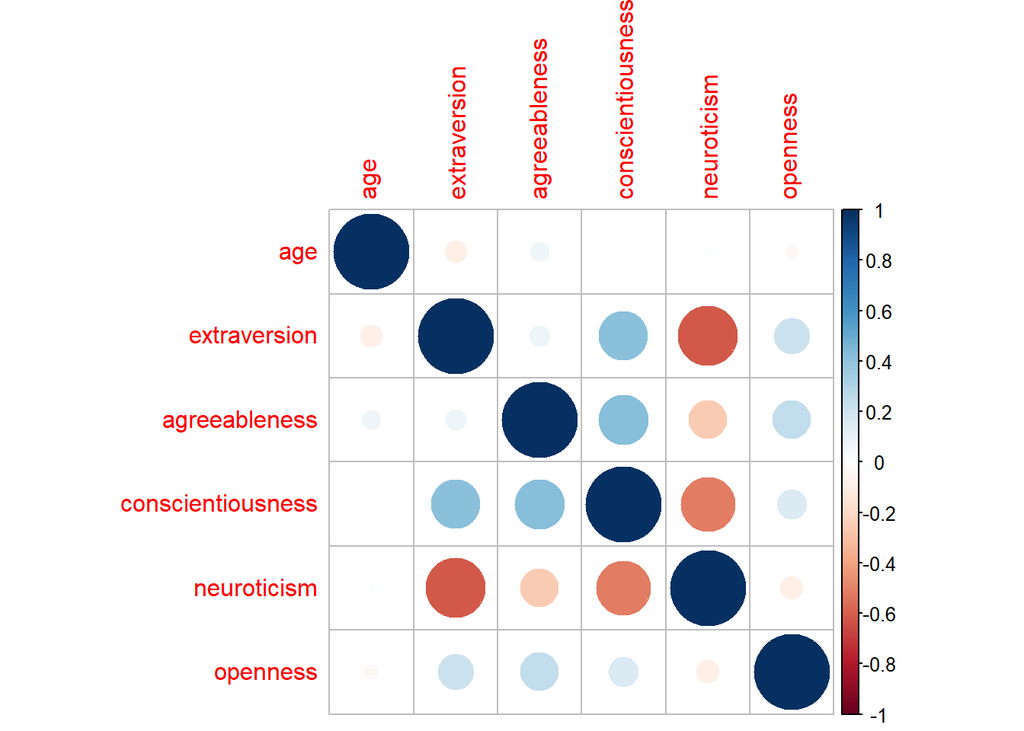

```r
vars <- data_clean %>%
  select(age, extraversion, agreeableness,
         conscientiousness, neuroticism, openness) %>%
  na.omit()

corrplot(cor(vars))
```

Korelacijska matrica dodatno potvrđuje izostanak snažnih povezanosti između dobi i pojedinih crta ličnosti.

```r
model_consc <- lm(conscientiousness ~ age, data = data_clean)
summary(model_consc)
```

```
##
## Call:
## lm(formula = conscientiousness ~ age, data = data_clean)
##
## Residuals:
##      Min       1Q   Median       3Q      Max
## -2.99434 -0.68117  0.01346  0.76485  2.34600
##
## Coefficients:
##              Estimate Std. Error t value Pr(>|t|)
## (Intercept)  0.099902   0.353798   0.282    0.778
## age         -0.001533   0.010973  -0.140    0.889
##
## Residual standard error: 0.9919 on 396 degrees of freedom
## Multiple R-squared:  4.929e-05,  Adjusted R-squared:  -0.002476
## F-statistic: 0.01952 on 1 and 396 DF,  p-value: 0.889
```

```r
model_extra <- lm(extraversion ~ age, data = data_clean)
summary(model_extra)
```

```
##
## Call:
## lm(formula = extraversion ~ age, data = data_clean)
##
## Residuals:
##     Min      1Q  Median      3Q     Max
## -3.1645 -0.6666  0.1027  0.7857  2.5834
##
## Coefficients:
##             Estimate Std. Error t value Pr(>|t|)
## (Intercept)  0.61250    0.38726   1.582   0.1145
## age         -0.02048    0.01201  -1.705   0.0889 .
## ---
## Signif. codes:  0 '***' 0.001 '**' 0.01 '*' 0.05 '.' 0.1 ' ' 1
##
## Residual standard error: 1.086 on 396 degrees of freedom
## Multiple R-squared:  0.00729,    Adjusted R-squared:  0.004783
## F-statistic: 2.908 on 1 and 396 DF,  p-value: 0.08893
```

```r
model_agree <- lm(agreeableness ~ age, data = data_clean)
summary(model_agree)
```

```
##
## Call:
## lm(formula = agreeableness ~ age, data = data_clean)
##
## Residuals:
##     Min      1Q  Median      3Q     Max
## -3.1780 -0.7163  0.0236  0.7345  2.6385
##
## Coefficients:
##             Estimate Std. Error t value Pr(>|t|)
## (Intercept) -0.39279    0.36742  -1.069    0.286
## age          0.01457    0.01140   1.279    0.202
##
## Residual standard error: 1.03 on 396 degrees of freedom
## Multiple R-squared:  0.004114,   Adjusted R-squared:  0.001599
## F-statistic: 1.636 on 1 and 396 DF,  p-value: 0.2017
```

```r
model_neuro <- lm(neuroticism ~ age, data = data_clean)
summary(model_neuro)
```

```
##
## Call:
## lm(formula = neuroticism ~ age, data = data_clean)
##
## Residuals:
##     Min      1Q  Median      3Q     Max
## -2.3342 -0.7428 -0.1191  0.6403  2.9115
##
## Coefficients:
##              Estimate Std. Error t value Pr(>|t|)
## (Intercept) -0.045980   0.376568  -0.122    0.903
## age          0.002866   0.011679   0.245    0.806
##
## Residual standard error: 1.056 on 396 degrees of freedom
## Multiple R-squared:  0.0001521,  Adjusted R-squared:  -0.002373
## F-statistic: 0.06022 on 1 and 396 DF,  p-value: 0.8063
```

```r
model_open <- lm(openness ~ age, data = data_clean)
summary(model_open)
```

```
##
## Call:
## lm(formula = openness ~ age, data = data_clean)
##
## Residuals:
##     Min      1Q  Median      3Q     Max
## -3.4319 -0.6082 -0.1301  0.6922  2.9697
##
## Coefficients:
##              Estimate Std. Error t value Pr(>|t|)
## (Intercept)  0.297455   0.373452   0.796    0.426
## age         -0.008046   0.011583  -0.695    0.488
##
## Residual standard error: 1.047 on 396 degrees of freedom
## Multiple R-squared:  0.001217,   Adjusted R-squared:  -0.001305
## F-statistic: 0.4825 on 1 and 396 DF,  p-value: 0.4877
```

Za svaku crtu ličnosti provedena je analiza jednostavne linearne regresije u kojoj je dob korištena kao nezavisna varijabla. U niti jednom modelu dob se nije pokazala statistički značajnim prediktorom (p > 0.05). Vrijednosti koeficijenta determinacije bile su vrlo niske, što upućuje na slab objašnjavajući doprinos dobi.

Na temelju provedene analize može se zaključiti da se u promatranom uzorku ne uočava statistički značajno jačanje niti slabljenje crta ličnosti s godinama. Dob se u ovom istraživanju nije pokazala značajnim prediktorom promjena u okviru Big Five modela ličnosti.

```r
library(broom)

models <- list(
  Extraversion = model_extra,
  Agreeableness = model_agree,
  Conscientiousness = model_consc,
  Neuroticism = model_neuro,
  Openness = model_open
)

results <- lapply(models, tidy) |>
  bind_rows(.id = "Trait") |>
  filter(term == "age")

results
```

| Trait | term | estimate | std.error | statistic | p.value |
| --- | --- | --- | --- | --- | --- |
| Extraversion | age | -0.020482383 | 0.01201112 | -1.7052843 | 0.08892563 |
| Agreeableness | age | 0.014574308 | 0.01139566 | 1.2789350 | 0.20166888 |
| Conscientiousness | age | -0.001533173 | 0.01097319 | -0.1397199 | 0.88895231 |
| Neuroticism | age | 0.002866128 | 0.01167940 | 0.2454002 | 0.80627369 |
| Openness | age | -0.008045858 | 0.01158277 | -0.6946402 | 0.48768815 |

Tablica prikazuje procijenjene regresijske koeficijente za učinak dobi na pojedine crte ličnosti.

Kategorizacija kontinuiranih varijabli provedena je radi primjene hi-kvadrat testa, kojim se ispituje povezanost između dobnih skupina i distribucije razina crta ličnosti.

```r
data_clean <- data_clean %>%
  mutate(age_group = case_when(
    age < 30 ~ "Mladi",
    age >= 30 & age < 35 ~ "Srednji",
    age >= 35 ~ "Stariji"
  ))

data_clean$age_group <- factor(data_clean$age_group)
```

Crte ličnosti podijeljene su u tri kategorije (niska, srednja i visoka razina) na temelju tercila distribucije rezultata.

```r
traits <- c("extraversion","agreeableness", "conscientiousness", "neuroticism", "openness")

for (t in traits) {
  data_clean[[paste0(t, "_cat")]] <- cut(
    data_clean[[t]],
    breaks = quantile(data_clean[[t]], probs = c(0, 1/3, 2/3, 1), na.rm = TRUE),
    labels = c("Niska", "Srednja", "Visoka"),
    include.lowest = TRUE
  )
}
```

```r
chisq.test(table(data_clean$age_group, data_clean$extraversion_cat))
```

```
##
##  Pearson's Chi-squared test
##
## data:  table(data_clean$age_group, data_clean$extraversion_cat)
## X-squared = 2.7214, df = 4, p-value = 0.6055
```

```r
chisq.test(table(data_clean$age_group, data_clean$agreeableness_cat))
```

```
##
##  Pearson's Chi-squared test
##
## data:  table(data_clean$age_group, data_clean$agreeableness_cat)
## X-squared = 8.7962, df = 4, p-value = 0.0664
```

```r
chisq.test(table(data_clean$age_group, data_clean$conscientiousness_cat))
```

```
##
##  Pearson's Chi-squared test
##
## data:  table(data_clean$age_group, data_clean$conscientiousness_cat)
## X-squared = 1.176, df = 4, p-value = 0.882
```

```r
chisq.test(table(data_clean$age_group, data_clean$neuroticism_cat))
```

```
##
##  Pearson's Chi-squared test
##
## data:  table(data_clean$age_group, data_clean$neuroticism_cat)
## X-squared = 5.0875, df = 4, p-value = 0.2784
```

```r
chisq.test(table(data_clean$age_group, data_clean$openness_cat))
```

```
##
##  Pearson's Chi-squared test
##
## data:  table(data_clean$age_group, data_clean$openness_cat)
## X-squared = 0.79106, df = 4, p-value = 0.9396
```

```r
table(data_clean$age_group, data_clean$openness_cat)
```

```
##
##           Niska Srednja Visoka
##   Mladi      44      44     48
##   Srednji    45      47     41
##   Stariji    44      41     44
```

Hi-kvadrat testom ispitana je povezanost između dobnih skupina i kategoriziranih razina crta ličnosti. Rezultati nisu pokazali statistički značajnu povezanost između dobi i ekstraverzije, savjesnosti, neuroticizma niti otvorenosti (p > 0.05).

Rezultati hi-kvadrat testova nisu pokazali statistički značajnu povezanost između dobnih skupina i osobina.

Kod osobine ugodnosti uočen je povišen hi-kvadrat rezultat (8.80), no pripadajuća p-vrijednost (0.066) ne doseže prag statističke značajnosti. Stoga se ne može zaključiti da se razine ugodnosti značajno razlikuju između dobnih skupina.

Iako je kod ugodnosti uočena blaga tendencija promjene raspodjele razina između dobnih skupina, ona nije statistički potvrđena, što može biti posljedica kategorizacije kontinuiranih varijabli i smanjene statističke snage hi-kvadrat testa.

Na temelju hi-kvadrat analize kategoriziranih varijabli ne može se zaključiti da se crte ličnosti značajno mijenjaju ili jačaju s godinama u promatranom uzorku.

```r
data_clean$occupation <- factor(data_clean$"employment status")
```

```r
data_clean$occupation <- fct_lump_min(
  data_clean$occupation,
  min = 10
)
```

```r
chisq.test(
  table(data_clean$occupation, data_clean$extraversion_cat),simulate.p.value = TRUE
)
```

```
##
##  Pearson's Chi-squared test with simulated p-value (based on 2000
##  replicates)
##
## data:  table(data_clean$occupation, data_clean$extraversion_cat)
## X-squared = 33.966, df = NA, p-value = 0.0004998
```

```r
chisq.test(
  table(data_clean$occupation, data_clean$agreeableness_cat),simulate.p.value = TRUE
)
```

```
##
##  Pearson's Chi-squared test with simulated p-value (based on 2000
##  replicates)
##
## data:  table(data_clean$occupation, data_clean$agreeableness_cat)
## X-squared = 6.2437, df = NA, p-value = 0.6247
```

```r
chisq.test(
  table(data_clean$occupation, data_clean$conscientiousness_cat),simulate.p.value = TRUE
)
```

```
##
##  Pearson's Chi-squared test with simulated p-value (based on 2000
##  replicates)
##
## data:  table(data_clean$occupation, data_clean$conscientiousness_cat)
## X-squared = 20.033, df = NA, p-value = 0.006497
```

```r
chisq.test(
  table(data_clean$occupation, data_clean$neuroticism_cat),simulate.p.value = TRUE
)
```

```
##
##  Pearson's Chi-squared test with simulated p-value (based on 2000
##  replicates)
##
## data:  table(data_clean$occupation, data_clean$neuroticism_cat)
## X-squared = 35.602, df = NA, p-value = 0.0004998
```

```r
chisq.test(
  table(data_clean$occupation, data_clean$openness_cat),simulate.p.value = TRUE
)
```

```
##
##  Pearson's Chi-squared test with simulated p-value (based on 2000
##  replicates)
##
## data:  table(data_clean$occupation, data_clean$openness_cat)
## X-squared = 10.37, df = NA, p-value = 0.2424
```

Zbog niskih očekivanih frekvencija u pojedinim ćelijama korištena je Monte Carlo simulacija p-vrijednosti.

Ovi nalazi upućuju na to da se razine pojedinih crta ličnosti razlikuju između skupina različitog zanimanja. Zanimanje se pokazalo značajno povezanim s ekstraverzijom, savjesnošću i neuroticizmom, dok za ugodnost i otvorenost takva povezanost nije utvrđena. Time se sugerira da socijalni i radni kontekst može biti povezan s izraženošću određenih crta ličnosti.

```r
library(rcompanion)
# Ekstraverzija
cramerV(table(data_clean$occupation, data_clean$extraversion_cat))
```

```
## Cramer V
##   0.2066
```

```r
prop_extr <- prop.table(
  table(data_clean$occupation, data_clean$extraversion_cat),
  1
)

round(prop_extr * 100, 1)
```

```
##
##                                                            Niska Srednja Visoka
##   Full-Time                                                 25.5    36.7   37.8
##   Not in paid work (e.g. homemaker', 'retired or disabled)  73.3    20.0    6.7
##   Part-Time                                                 42.9    23.2   33.9
##   Unemployed (and job seeking)                              57.1    25.0   17.9
##   Other                                                     52.4    33.3   14.3
```

```r
# Savjesnost
cramerV(table(data_clean$occupation, data_clean$conscientiousness_cat))
```

```
## Cramer V
##   0.1586
```

```r
prop_consc <- prop.table(
  table(data_clean$occupation, data_clean$conscientiousness_cat),
  1
)

round(prop_consc * 100, 1)
```

```
##
##                                                            Niska Srednja Visoka
##   Full-Time                                                 30.9    32.4   36.7
##   Not in paid work (e.g. homemaker', 'retired or disabled)  33.3    53.3   13.3
##   Part-Time                                                 28.6    33.9   37.5
##   Unemployed (and job seeking)                              64.3    21.4   14.3
##   Other                                                     38.1    42.9   19.0
```

```r
# Neuroticizam
cramerV(table(data_clean$occupation, data_clean$neuroticism_cat))
```

```
## Cramer V
##   0.2115
```

```r
prop_neuro <- prop.table(
  table(data_clean$occupation, data_clean$neuroticism_cat),
  1
)

round(prop_neuro * 100, 1)
```

```
##
##                                                            Niska Srednja Visoka
##   Full-Time                                                 38.1    33.8   28.1
##   Not in paid work (e.g. homemaker', 'retired or disabled)   6.7    13.3   80.0
##   Part-Time                                                 32.1    41.1   26.8
##   Unemployed (and job seeking)                              14.3    21.4   64.3
##   Other                                                     19.0    33.3   47.6
```

Dok analize prema dobnim skupinama nisu pokazale statistički značajne razlike u crtama ličnosti, rezultati prema zanimanju sugeriraju da se ekstraverzija, savjesnost i neuroticizam mogu razlikovati ovisno o socijalnom/profesionalnom kontekstu, a ne nužno o kronološkoj dobi.

Ukupno gledano, zanimanje je statistički značajno povezano s ekstraverzijom, savjesnošću i neuroticizmom, pri čemu su efekti slabi do umjereni; pritom se u skupinama nezaposlenih i osoba izvan plaćenog rada češće uočavaju nepovoljniji profili (niža savjesnost i viši neuroticizam), dok su zaposleni s punim radnim vremenom češće u niskom/srednjem neuroticizmu te srednjoj/visokoj savjesnosti i ekstraverziji.

Budući da su skupine zanimanja različitih veličina, zaključci se temelje na relativnim razlikama u raspodjelama (udjelima) kategorija unutar skupina, a ne na apsolutnim frekvencijama.

```r
make_percent_table <- function(x, row_var, col_var) {
  tab <- prop.table(table(x[[ row_var]], x[[col_var]]), 1) * 100
  df <- as.data.frame.matrix(round(tab, 1))
  df[[ row_var]] <- rownames(df)
  rownames(df) <- NULL
  df <- df[, c(row_var, colnames(df)[colnames(df) != row_var])]
  df
}

df_extr  <- make_percent_table(data_clean, "occupation", "extraversion_cat")
df_consc <- make_percent_table(data_clean, "occupation", "conscientiousness_cat")
df_neuro <- make_percent_table(data_clean, "occupation", "neuroticism_cat")

df_extr
```

| occupation | Niska | Srednja | Visoka |
| --- | --- | --- | --- |
| Full-Time | 25.5 | 36.7 | 37.8 |
| Not in paid work (e.g. homemaker', 'retired or disabled) | 73.3 | 20.0 | 6.7 |
| Part-Time | 42.9 | 23.2 | 33.9 |
| Unemployed (and job seeking) | 57.1 | 25.0 | 17.9 |
| Other | 52.4 | 33.3 | 14.3 |

```r
df_consc
```

| occupation | Niska | Srednja | Visoka |
| --- | --- | --- | --- |
| Full-Time | 30.9 | 32.4 | 36.7 |
| Not in paid work (e.g. homemaker', 'retired or disabled) | 33.3 | 53.3 | 13.3 |
| Part-Time | 28.6 | 33.9 | 37.5 |
| Unemployed (and job seeking) | 64.3 | 21.4 | 14.3 |
| Other | 38.1 | 42.9 | 19.0 |

```r
df_neuro
```

| occupation | Niska | Srednja | Visoka |
| --- | --- | --- | --- |
| Full-Time | 38.1 | 33.8 | 28.1 |
| Not in paid work (e.g. homemaker', 'retired or disabled) | 6.7 | 13.3 | 80.0 |
| Part-Time | 32.1 | 41.1 | 26.8 |
| Unemployed (and job seeking) | 14.3 | 21.4 | 64.3 |
| Other | 19.0 | 33.3 | 47.6 |

# Jesu li crte ličnosti i sklonost stresu, depresiji i anksioznosti povezane sa zanimanjem?

```r
df_job <- dataset %>% filter(!sex %in% c("CONSENT_REVOKED"),
                             !`student status` %in% c("CONSENT_REVOKED", "DATA_EXPIRED"),
                             !`employment status` %in% c("CONSENT_REVOKED", "DATA_EXPIRED")
                             )
```

```r
df_job <- df_job %>% mutate(
    occupation_group = if_else(
      `student status` == "Yes",
      "Student",
      `employment status`
    )
  ) %>% filter(!occupation_group %in% c("Other", "Due to start a new job within the next month", "Not in paid work (e.g. homemaker', 'retired or disabled)"))

table(df_job$occupation_group)
```

```
##
##                    Full-Time                    Part-Time
##                          205                           36
##                      Student Unemployed (and job seeking)
##                          109                           24
```

```r
df_job %>%
  group_by(occupation_group) %>%
  summarise(
    n = n(),
    mean_stress = mean(stress, na.rm = TRUE),
    mean_depression = mean(depression, na.rm = TRUE),
    mean_anxiety = mean(anxiety, na.rm = TRUE)
  )
```

| occupation_group | n | mean_stress | mean_depression | mean_anxiety |
| --- | --- | --- | --- | --- |
| Full-Time | 205 | -0.07389305 | -0.04661796 | -0.03418783 |
| Part-Time | 36 | 0.07561649 | 0.12665201 | 0.10666582 |
| Student | 109 | 0.07394421 | 0.01260268 | -0.06773724 |
| Unemployed (and job seeking) | 24 | 0.10860142 | 0.56128384 | 0.34640394 |

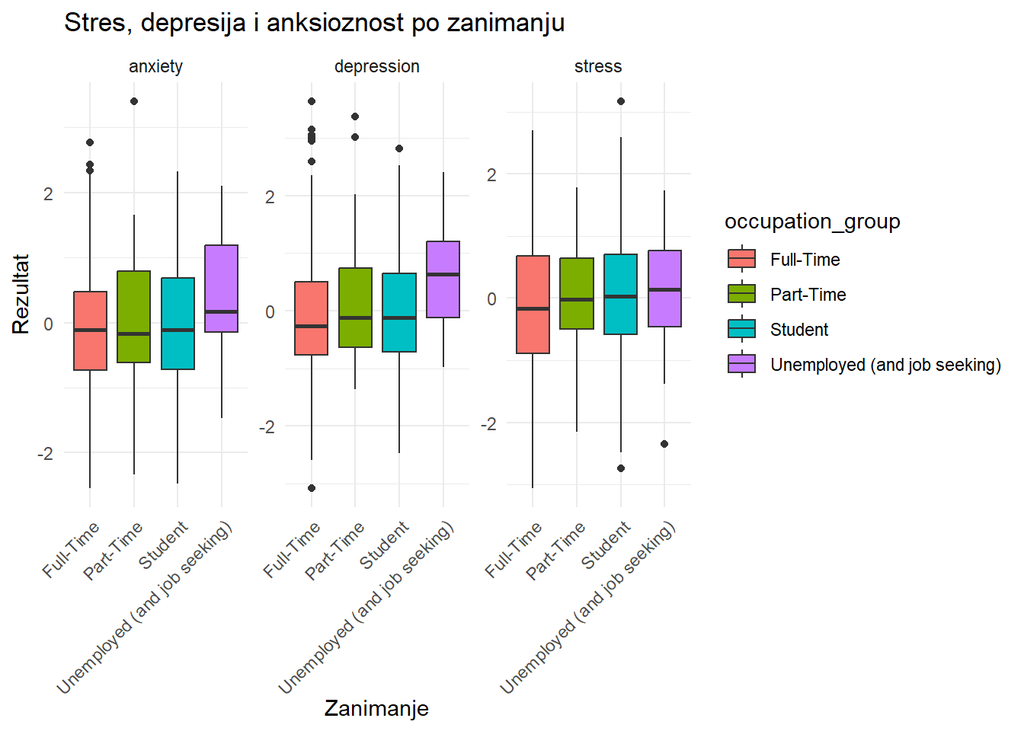

```r
mental_long <- df_job %>%
  pivot_longer(
    cols = c(stress, depression, anxiety),
    names_to = "outcome",
    values_to = "score"
  )

ggplot(mental_long, aes(x = occupation_group, y = score, fill = occupation_group)) +
  geom_boxplot() +
  facet_wrap(~ outcome, scales = "free_y") +
  theme_minimal() +
  theme(axis.text.x = element_text(angle = 45, hjust = 1)) +
  labs(
    title = "Stres, depresija i anksioznost po zanimanju",
    x = "Zanimanje",
    y = "Rezultat"
  )
```

## Provođenje ANOVA analize - Razlikuju li se razine anksioznosti, depresije i stresa po zanimanjima?

Test pretpostavke normalnosti za anksioznost

```r
require(nortest)
lillie.test(df_job$anxiety)
```

```
##
##  Lilliefors (Kolmogorov-Smirnov) normality test
##
## data:  df_job$anxiety
## D = 0.040688, p-value = 0.1385
```

```r
lillie.test(df_job$anxiety[df_job$occupation_group=='Full-Time'])
```

```
##
##  Lilliefors (Kolmogorov-Smirnov) normality test
##
## data:  df_job$anxiety[df_job$occupation_group == "Full-Time"]
## D = 0.060222, p-value = 0.06789
```

```r
lillie.test(df_job$anxiety[df_job$occupation_group=='Part-Time'])
```

```
##
##  Lilliefors (Kolmogorov-Smirnov) normality test
##
## data:  df_job$anxiety[df_job$occupation_group == "Part-Time"]
## D = 0.15146, p-value = 0.03593
```

```r
lillie.test(df_job$anxiety[df_job$occupation_group=='Unemployed (and job seeking)'])
```

```
##
##  Lilliefors (Kolmogorov-Smirnov) normality test
##
## data:  df_job$anxiety[df_job$occupation_group == "Unemployed (and job seeking)"]
## D = 0.11293, p-value = 0.5953
```

```r
lillie.test(df_job$anxiety[df_job$occupation_group=='Student'])
```

```
##
##  Lilliefors (Kolmogorov-Smirnov) normality test
##
## data:  df_job$anxiety[df_job$occupation_group == "Student"]
## D = 0.042081, p-value = 0.9066
```

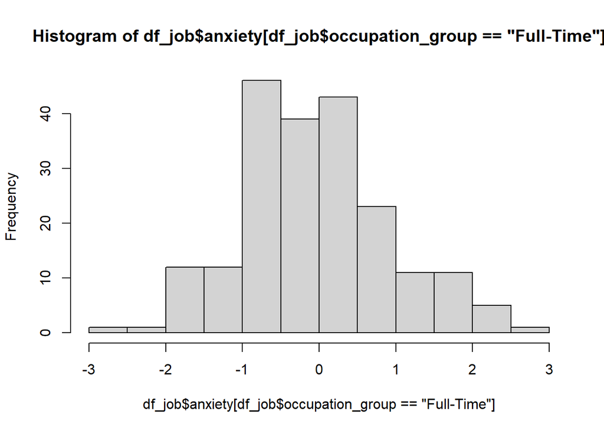

```r
hist(df_job$anxiety[df_job$occupation_group=='Full-Time'])
```

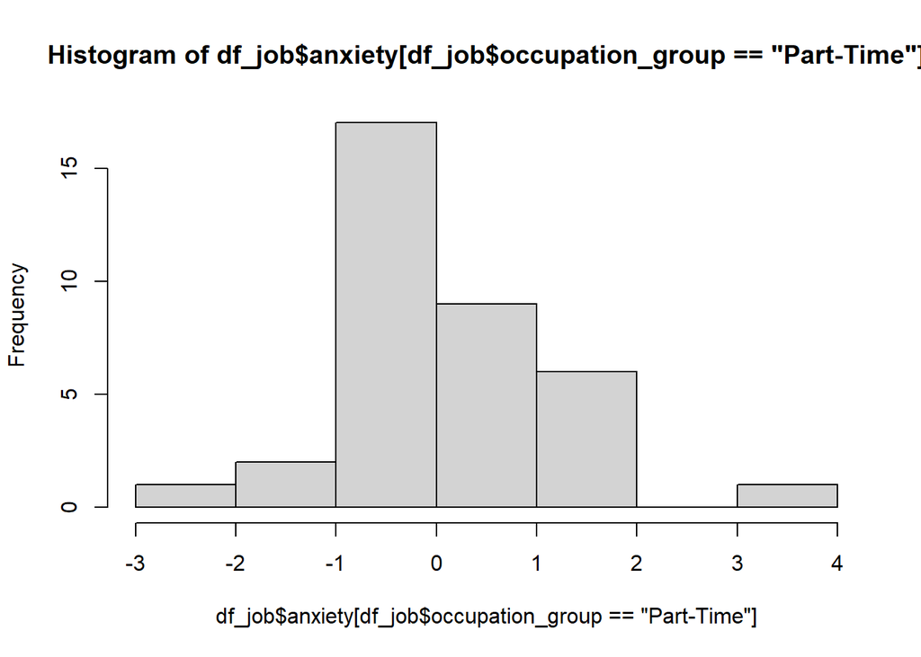

```r
hist(df_job$anxiety[df_job$occupation_group=='Part-Time'])
```

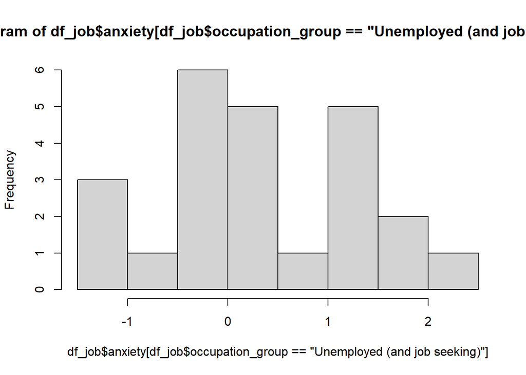

```r
hist(df_job$anxiety[df_job$occupation_group=='Unemployed (and job seeking)'])
```